# Recolector de redes inalámbricas · Fase 1

*Guía paso a paso para aprender C construyendo la Entrega 1 · Arquitectura de Sistemas 2026-2027*

# Empieza aquí

## Qué vas a construir

Un programa de terminal en C con un menú. Para la **Entrega 1** (Fase 1) basta con cuatro operaciones:

| Opción | Operación | Qué hace |
| --- | --- | --- |
| 1 | `wificollector_quit` | Pregunta si de verdad quieres salir |
| 2 | `wificollector_collect` | Lee un fichero `info_cell_N.txt` y añade sus puntos de acceso a un array |
| 9 | `wificollector_display` | Imprime los puntos de acceso de la celda que elijas |
| 10 | `wificollector_display_all` | Imprime todos los puntos de acceso guardados |

Restricciones de la Fase 1 (del enunciado y de lo que me has pedido):

- **Array de tamaño fijo, máximo 200 elementos.** Cadenas de texto de **80 caracteres como máximo**.
- Sin arrays dinámicos ni memoria dinámica (`malloc`/`realloc` llegan en la Entrega 2).
- **Si no compila con `gcc -Wall` sin errores ni advertencias, la nota es 0.** Por eso en cada etapa compilarás con ese flag.
- Código dividido en ficheros, documentado y escrito siguiendo la *Guía de estilo*.
- Se entrega un `.zip` con: ficheros de entrada, código fuente, `Makefile` y `README`. Tiene que compilar con `make` y ejecutarse con `./main`, y funcionar en los laboratorios o máquinas virtuales de la UC3M.
- **Fecha límite según el enunciado: viernes 16 de octubre de 2026, 23:55** (Aula Global).

## Cómo usar esta guía (el método)

El objetivo no es solo entregar: es que dentro de unas semanas puedas escribir esto **sin ayuda**. Para eso, cada etapa sigue el mismo ciclo:

1. **Lee** el objetivo y la teoría (son cortas y van al grano).
2. **Mira el diagrama** de flujo: es el “plano” de lo que vas a escribir.
3. **Intenta tú** escribir el código usando solo la *ficha* de la etapa (nombres de funciones y qué debe hacer cada una). Si te atascas, usa las **pistas** en orden.
4. **Compila con `-Wall` y prueba** con la tabla de pruebas de la etapa.
5. **Compara** con mi solución de referencia (desplegable al final de cada etapa, o la carpeta `etapa_N/`). No busques que sea idéntica: busca **entender cada diferencia**.
6. **Reescribe sin mirar** la función más difícil de la etapa. Si te sale, lo has aprendido; si no, vuelve a la teoría.

> **Regla de oro:** escribe todo a mano, aunque tengas la solución delante. Copiar y pegar te da un programa; teclear, equivocarte y arreglarlo te da la habilidad que necesitarás en los exámenes.

> **No mires las etapas siguientes** hasta terminar la actual. Cada carpeta `etapa_N/` es un programa completo que compila y funciona, para que puedas comparar o retomar desde ahí si algo se rompe.

## Mapa de etapas

| Etapa | Qué construyes | Conceptos de C que aprendes | Carpeta |
| --- | --- | --- | --- |
| 0 | Preparación y mapa del proyecto | Cómo se compila un programa, módulos, estilo | — |
| 1 | `input.c/.h`: leer del teclado sin que nada se rompa | cadenas, `fgets`, `sscanf`, `EOF`, parámetros array | `etapa_1/` |
| 2 | Menú principal, bucle y `quit` + `Makefile` | `while`, `switch`, `enum`, `static`, varios ficheros, `make` | `etapa_2/` |
| 3 | La estructura `wifi_cell` y mostrar una celda | `struct`, `strcpy`, `printf`, arrays de structs | `etapa_3/` |
| 4 | Leer un bloque de un fichero de texto | ficheros, `FILE *`, `fopen`, scansets, arrays 2D, `enum` de estado | `etapa_4/` |
| 5 | `wificollector_collect` | estado de módulo, límites de un array, `snprintf`, descomponer en funciones | `etapa_5/` |
| 6 | `display` y `display_all` | búsqueda lineal, contar, reutilizar funciones | `etapa_6/` |
| 7 | Pruebas, estilo y entrega | probar con redirección, revisar estilo, `README`, `zip` | `etapa_7_entrega_final/` |

## Ritmo sugerido (hoy es martes 6 de octubre)

| Cuándo | Etapa |
| --- | --- |
| Mar 6 – Mié 7 oct | 0 y 1 |
| Jue 8 | 2 |
| Vie 9 | 3 |
| Sáb 10 – Dom 11 | 4 (la más densa en conceptos nuevos) |
| Lun 12 – Mar 13 | 5 |
| Mié 14 | 6 |
| Jue 15 | 7: pruebas, estilo, README, zip |
| Vie 16 | Colchón. Entrega con margen, **no a las 23:50** |

> Si trabajas en equipo (el enunciado pide equipos de 3 y contribución equilibrada), una buena idea es que los tres hagáis las etapas 1-4 por separado —así aprendéis los tres— y luego decidáis juntos con qué versión os quedáis.

## Qué contiene el paquete

```
wificollector_fase1/
├── GUIA_Fase1.html          ← esta guía en una sola página (se lee en el navegador)
├── guia/                    ← la misma guía en ficheros Markdown, una etapa por fichero
├── diagramas/               ← todos los diagramas (PNG para ver, SVG para ampliar, DOT = código fuente)
├── etapa_1/ … etapa_6/      ← el programa tal y como queda al terminar cada etapa
└── etapa_7_entrega_final/   ← versión final: código, Makefile, README (plantilla), tests y datos
```

## Cómo leer los diagramas

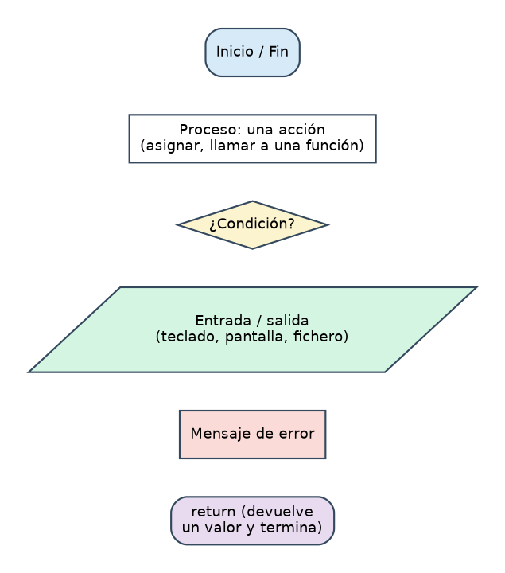

Leyenda de los diagramas de flujo

## Una nota honesta sobre “sin punteros”

En la Fase 1 **no declararás ninguna variable puntero, ni usarás `malloc`/`realloc`**. Pero C tiene tres sitios donde los punteros asoman aunque no los escribas, y es mejor que sepas qué son para que no te sorprendan:

1. **`FILE *`**: el tipo que devuelve `fopen`. Tendrás una variable `FILE *file`. Trátala como un “manillar” opaco: la pasas a `fgets` y `fclose`, y nunca miras dentro.
2. **El operador `&`** en `sscanf(line, "%d", &number)`: significa “la dirección de `number`” y le dice a `sscanf` *dónde escribir* el resultado. Sin él, `sscanf` no tendría forma de modificar tu variable.
3. **Los parámetros array** (`char line[]`): cuando pasas un array a una función, **no se copia**; la función recibe la dirección del original. Por eso `input_read_line(line, size)` puede rellenar tu `line`. Y también por eso, dentro de la función, `sizeof(line)` **no** te da el tamaño del array (por eso pasamos `size` aparte).

Todo esto se entenderá a fondo cuando lleguen los punteros y la memoria dinámica (Entregas 2 y 3). Por ahora, con “`&` = dónde escribir” y “los arrays se pasan sin copiar” tienes suficiente.

## Decisiones que he tomado (puedes cambiarlas)

El enunciado deja algunos detalles abiertos. Las he resuelto así y las documento también en el `README`:

- **Mensajes en español**, como el enunciado. (El ejemplo del mensaje de la Fase I está en inglés, pero dice expresamente que no hace falta el formato exacto.)
- **Sí/no:** se aceptan `s`, `S`, `n`, `N`. Cualquier otra cosa, incluida una línea vacía, se rechaza y se vuelve a preguntar.
- **`collect` no comprueba duplicados:** si recolectas dos veces la misma celda, se añade dos veces. El enunciado solo pide ignorar duplicados en `import`.
- **Si un bloque del fichero está mal formado**, se conservan los bloques anteriores ya añadidos, se avisa del error y se ignora el resto de ese fichero.
- **Si el array se llena** (200), se avisa y no se añade nada más.
- **Si se acaba la entrada** (Ctrl+D o fichero redirigido), el programa termina limpiamente en vez de quedarse en un bucle infinito.

> Si dudas de alguna de estas decisiones, pregúntala en tutoría: son exactamente el tipo de detalle que el cliente “puede ajustar durante el desarrollo” (aviso del enunciado).

# Etapa 0 · Preparación y mapa del proyecto

> **Objetivo:** entender qué hay que construir, cómo encajan las piezas y dejar el entorno listo. **No hay código que escribir hoy**, salvo un “hola mundo” de comprobación.

## 0.1 Los datos: de qué está hecho un fichero `info_cell_N.txt`

Cada fichero contiene uno o varios **bloques de 9 líneas**. Cada bloque es un punto de acceso wifi. Esto es `info_cell_5.txt` (3 bloques):

```
Cell 5
Address: 00:23:F8:B5:CD:22
ESSID:"WLAN_58"
Mode:Master
Channel:9
Encryption key:on
Quality=28/70
Frequency:2.452 GHz
Signal level=-82 dBm
Cell 5
Address: 00:1C:10:44:32:5B
...
```

He comprobado los 21 ficheros: todos tienen bloques de exactamente 9 líneas, sin líneas en blanco, la frecuencia siempre está en GHz y hay 47 bloques en total: las celdas 1 a 6 tienen 3 bloques, de la 7 a la 20 tienen 2 y la 21 tiene 1. Fíjate también en que un ESSID puede tener **espacios** (`"Miguel 3"`): lo tendrás en cuenta en la Etapa 4.

## 0.2 Vista general del programa

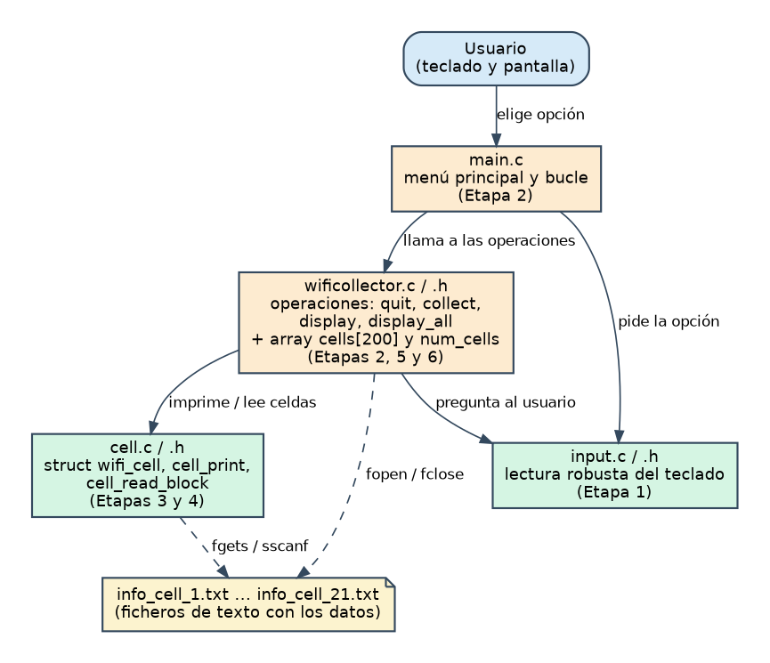

Módulos del programa y cómo se llaman entre sí

Cada recuadro es un **módulo**: una pareja `.c` (implementación) + `.h` (lo que ofrece a los demás). Las flechas dicen “usa a”. Observa que `main.c` no sabe nada de ficheros ni de structs: solo pide opciones y llama a `wificollector_*`. Esa separación es la clave de un programa fácil de mantener.

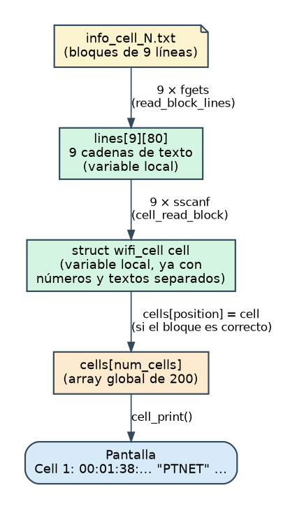

El viaje de un dato: del fichero a la pantalla

Este segundo diagrama es el **corazón** del proyecto: el texto de un fichero se lee línea a línea, se trocea en campos (números y cadenas), se guarda en una `struct` y esa `struct` se copia a un array. Cuando termines la Etapa 6 entenderás cada flecha.

## 0.3 Teoría: cómo se convierte un `.c` en un programa

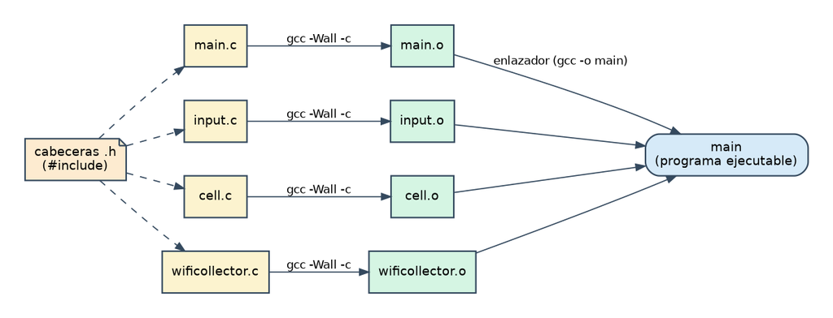

Compilación por módulos con gcc y make

Compilar no es un solo paso:

1. **Preprocesador:** procesa las líneas que empiezan por `#`. `#include "input.h"` pega el contenido de ese fichero; `#define MAX 80` sustituye `MAX` por `80` en todo el texto.
2. **Compilador:** traduce cada `.c` por separado a código máquina (un fichero objeto `.o`). Aquí aparecen los **errores de sintaxis** y las **advertencias** (*warnings*). Para compilar el `.c` necesita *conocer* las funciones que usas, y eso lo consigue leyendo sus **prototipos** en los `.h`.
3. **Enlazador (*linker*):** junta todos los `.o` en el ejecutable y comprueba que cada función usada **existe** en algún `.o`. Aquí aparece el error `undefined reference to ...` cuando declaras una función en un `.h` pero nunca la escribes.

¿Por qué separar en módulos? Porque si cambias un solo `.c`, solo se recompila ese; y porque cada módulo se puede probar por separado (lo harás en las etapas 1, 3 y 4).

**`-Wall`** activa casi todas las advertencias útiles (variables sin usar, formatos de `printf` incorrectos, funciones sin declarar…). Un *warning* suele ser un error real que el compilador te perdona. En esta asignatura **cero advertencias** es obligatorio.

## 0.4 Requisitos de la empresa y dónde se cumplen

| Requisito (enunciado) | Cómo lo cumpliremos |
| --- | --- |
| `company_require_divided` | Módulos `input`, `cell`, `wificollector` y `main`, con nombres descriptivos |
| `company_require_documented` | Comentario sobre **cada** función, `#define`, `struct`, `enum` y variable global |
| `company_require_gccclean` | Compilar siempre con `gcc -Wall`; cero advertencias |
| `company_require_style` | Resumen de la guía en la tabla de abajo; revisión en la Etapa 7 |
| `company_require_noleaks` | No aplica aún (sin memoria dinámica): llegará en la Entrega 2 |
| Compila en laboratorios/VM UC3M | Pruébalo allí en la Etapa 7, **no el último día** |

## 0.5 La *Guía de estilo*, resumida

Tenla a mano en cada etapa. (Es un resumen del documento oficial de la asignatura; ante la duda, manda el original.)

| Regla | Qué dice | Ejemplo |
| --- | --- | --- |
| A1 | Nombres cortos, descriptivos y concretos | `input_ask_number`, no `f2` |
| A2 | Variables y funciones en minúsculas con `_` | `num_cells`, `print_menu` |
| A3 | Macros y constantes en MAYÚSCULAS | `#define WFC_MAX_CELLS 200` |
| A4 | Constantes y enumerados públicos con prefijo de 3-4 letras del módulo | `INP_EOF`, `CEL_MAX_STR`, `WFC_…` |
| B1 | Sangría con **tabuladores** (editor configurado a 4 espacios), nunca espacios | — |
| B2 | Llaves en estilo Allman: la `{` en su propia línea | ver abajo |
| B3 | Espacio alrededor de operadores y tras `if`, `for`, `while`, `return` | `if (a == b)` |
| B4 | Una función debe caber en pantalla (nunca más de dos pantallas) | — |
| B5 | Líneas de **80 caracteres como máximo** | — |
| C1 | Tamaños de array con macros, no con números sueltos | `char line[INP_MAX_LINE];` |
| D1 | Comentario encima de **toda** función (qué hace, en 1-2 líneas) | ver abajo |
| D2 | Comentar las partes no triviales, no cada línea | — |
| E1-E3 | Cada `.c` tiene su `.h` y lo incluye el primero | `input.c` → `#include "input.h"` |
| E4 | El `.h` solo lleva lo público: tipos, constantes, prototipos | — |
| E5 | Guarda en todo `.h`: `#ifndef _X_H_` / `#define _X_H_` / `#endif` | — |
| E6 | El `.h` incluye solo lo imprescindible para compilar solo | — |
| E7 | Lo privado es `static`; las globales, juntas al principio del `.c` | — |

```c
/*
 * db_sync()
 * Comentario encima de la función: qué hace, en una o dos líneas.
 */
int db_sync(void)
{
    int i;

    for (i = 0; i < 10; i++)
    {
        if (i == 5)
        {
            continue;
        }
    }

    return i;
}
```

## 0.6 Tu tarea de hoy

1. Crea una carpeta de trabajo, por ejemplo `wificollector/`, y **copia dentro los 21 ficheros** `info_cell_N.txt`.
2. Comprueba que tienes `gcc` y `make`:

   ```
   gcc --version
   make --version
   ```

3. **Configura tu editor** para que el tabulador sea un tabulador de ancho 4. En VS Code: abre *Settings* y pon `editor.insertSpaces` en **falso**, `editor.tabSize` en **4** y `editor.detectIndentation` en **falso**. Añade también `editor.rulers: [80]` para ver una raya en la columna 80.
4. Escribe y compila un programa mínimo, y **provoca una advertencia a propósito** para ver cómo es:

   ```c
   #include <stdio.h>

   int main(void)
   {
    int unused;

    printf("Hola\n");
    return 0;
   }
   ```

   Compila con `gcc -Wall -o hola hola.c` y lee el mensaje (`unused variable`). Bórrala y vuelve a compilar: silencio total es lo que buscamos.

## 0.7 Recursos

- Compilación y avisos: [Opciones de aviso de GCC](https://gcc.gnu.org/onlinedocs/gcc/Warning-Options.html)
- Para empezar con el lenguaje (gratis, en inglés, muy claro): [Beej’s Guide to C Programming](https://beej.us/guide/bgc/) · y su [referencia de funciones de la librería estándar](https://beej.us/guide/bgclr/)
- Estilo de llaves: [Estilo Allman](https://en.wikipedia.org/wiki/Indentation_style#Allman_style)
- Libro clásico: *El lenguaje de programación C*, de Kernighan y Ritchie.
- En tu terminal tienes un manual de cada función: `man 3 fgets`, `man 3 sscanf`… (sal con `q`).

> Los enlaces apuntan a documentación oficial; si alguno cambia, busca el nombre de la función en [cppreference.com](https://en.cppreference.com/w/c).

## 0.8 Lista de comprobación

- Tengo la carpeta con los 21 ficheros de datos
- `gcc` y `make` funcionan
- El editor usa tabuladores de ancho 4 y tengo la raya de la columna 80
- He visto una advertencia de `-Wall` y sé leerla
- Puedo explicar con mis palabras qué hace el compilador y qué hace el enlazador

# Etapa 1 · Leer del teclado sin que el programa se rompa

> **Objetivo:** crear el módulo `input` (`input.h` + `input.c`) con tres funciones que lean números y respuestas sí/no **sin fallar nunca**, pase lo que pase en el teclado. **Dificultad:** media. **Tiempo orientativo:** 1-2 sesiones.

El enunciado insiste: *“la aplicación debe ser robusta: letras cuando se espera un número, una cadena vacía, una línea vacía…”*. Si dejas esto bien hecho **ahora**, todas las demás etapas se apoyan en ello y no tendrás que preocuparte más del teclado.

## 1.1 Teoría

### Cadenas de texto en C

C no tiene un tipo “texto”. Una **cadena** es un array de `char` que termina en un carácter especial `'\0'` (el *terminador*, valor 0).

```c
char line[80];   /* reserva 80 bytes: caben 79 letras + el '\0' */
```

- `"a"` (comillas dobles) es una cadena: dos bytes, `'a'` y `'\0'`. `'a'` (comillas simples) es un solo carácter. No son lo mismo.
- `strlen(line)` (de `<string.h>`) cuenta cuántos caracteres hay **antes** del `'\0'`.
- Un array no se puede asignar con `=` ni comparar con `==`. Para copiar y comparar cadenas hay funciones (`strcpy`, `strcmp`); las verás en las etapas siguientes.

### Por qué NO usar `scanf` para leer del teclado

`scanf("%d", &n)` parece cómodo, pero tiene tres problemas serios:

1. **Deja el salto de línea (`\n`) sin leer**, que “contamina” la siguiente lectura.
2. **Si escribes texto donde espera un número** (`abc`), `scanf` falla *sin consumir* esas letras. Si lo metes en un bucle “repite hasta que sea válido”, **se vuelve infinito**: lee `abc`, falla, lo vuelve a intentar con las mismas `abc`, falla…
3. Con `%s` y sin límite de anchura, **escribe más allá del array** (desbordamiento de buffer), uno de los fallos de seguridad más famosos de la historia.

La estrategia robusta es siempre la misma: **(1) leer una línea entera como texto, (2) analizarla con calma**.

### `fgets`: leer una línea entera

```c
char *fgets(char *buffer, int size, FILE *stream);
```

Lee como máximo `size - 1` caracteres de `stream` (para el teclado, `stdin`), se detiene tras el `'\n'` (que **se guarda** en el buffer) y añade el `'\0'`. Devuelve `NULL` si no pudo leer nada (fin de la entrada). `NULL` significa “nada / no hay”; de momento solo necesitas saber compararlo: `if (fgets(...) == NULL)`.

Dos situaciones a vigilar:

- **La línea cabe:** el buffer acaba en `"...\n\0"`. Hay que quitar el `\n` (poner un `'\0'` en su lugar).
- **La línea es demasiado larga:** `fgets` solo coge `size - 1` caracteres y el **resto se queda esperando** en el teclado, y se lo comerá la siguiente lectura. Hay que descartarlo leyendo con `getchar()` hasta encontrar `'\n'` o `EOF`.

### `sscanf`: analizar un texto que ya tienes

`sscanf` es `scanf` pero leyendo de una cadena en vez del teclado:

```c
int sscanf(const char *text, const char *format, ...);
```

Devuelve **cuántos datos consiguió convertir**. Eso es justo lo que necesitas para validar:

| Texto | `sscanf(text, "%d", &n)` devuelve |
| --- | --- |
| `"12"` | 1 (convirtió el número) |
| `"abc"` | 0 (no pudo convertir) |
| `""` (vacío) | -1 = `EOF` (no había nada) |
| `"12abc"` | 1 (¡acepta el 12 y se olvida de `abc`!) |

Ese último caso es un problema: `12abc` no debería ser válido. **El truco** es pedir a continuación un carácter extra con `"%d %c"`:

| Texto | `sscanf(text, "%d %c", &n, &extra)` | ¿Válido? |
| --- | --- | --- |
| `"12"` | 1 | sí |
| `" 7 "` | 1 | sí (el espacio del formato se come blancos) |
| `"12abc"` | 2 (encontró un `a` detrás) | **no** |
| `"5 6"` | 2 | **no** |

Es decir: el número es válido **solo si `sscanf` devuelve exactamente 1**. Luego se comprueba el rango (`min <= n <= max`).

> El `&` delante de `n` es el operador “dirección de”: le dice a `sscanf` *dónde* guardar el resultado (ver la nota “sin punteros” de la portada).

### `EOF`: cuando se acaba la entrada

Con **Ctrl+D** (Linux/Mac; Ctrl+Z+Enter en Windows) cierras la entrada de teclado. Lo mismo ocurre cuando ejecutas `./main < pruebas.txt` y el fichero se acaba. `fgets` devuelve entonces `NULL`. **Si tu bucle de “repite hasta que sea válido” no contempla esto, se queda dando vueltas para siempre.** Por eso nuestras funciones devuelven un valor especial (`INP_EOF`) cuando la entrada se acaba.

### Parámetros que son arrays

```c
int input_read_line(char line[], int size);
```

El array **no se copia**: la función trabaja sobre el array original de quien la llama (por eso puede rellenarlo). Por eso también hay que pasar `size` aparte. Y `const char question[]` es la promesa de “solo lo leeré, no lo modificaré”.

### Módulos: `.h` y `.c`

Es tu primer módulo. Recuerda las reglas E1-E7 de la guía de estilo: el `.h` lleva la **guarda** (`#ifndef _INPUT_H_ ... #endif`, para que incluirlo dos veces no dé error) y solo lo público; el `.c` incluye su propio `.h` y declara sus macros privadas. Las macros públicas llevan el prefijo del módulo: `INP_`.

## 1.2 Diagramas de flujo

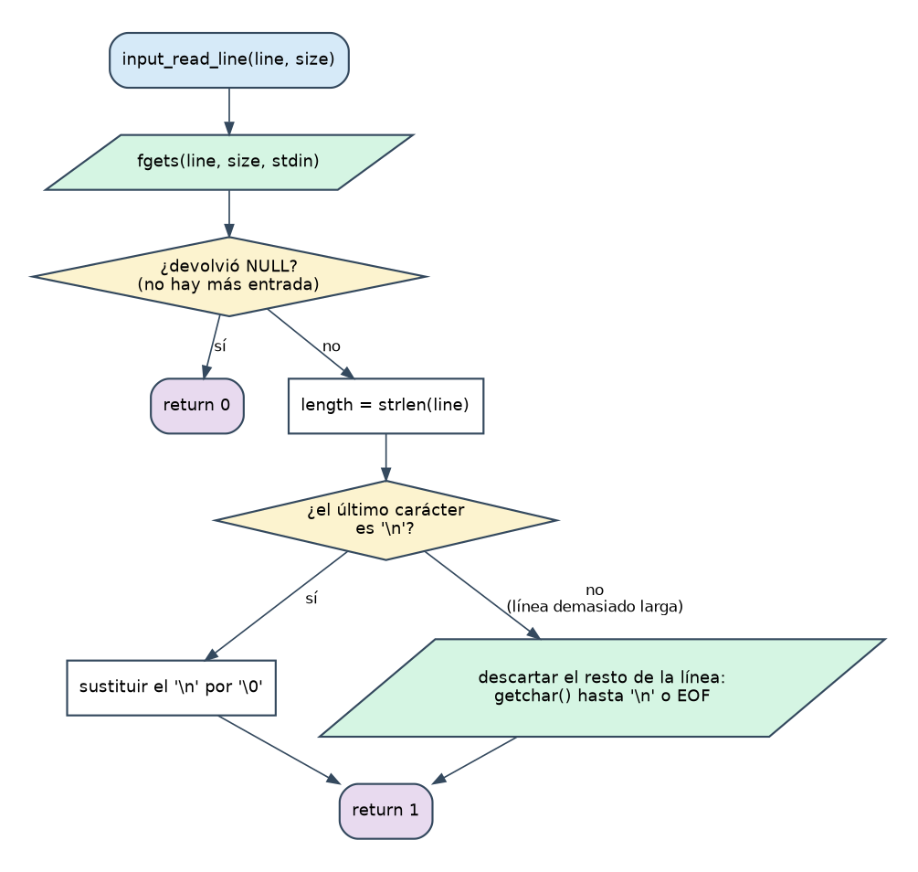

input_read_line

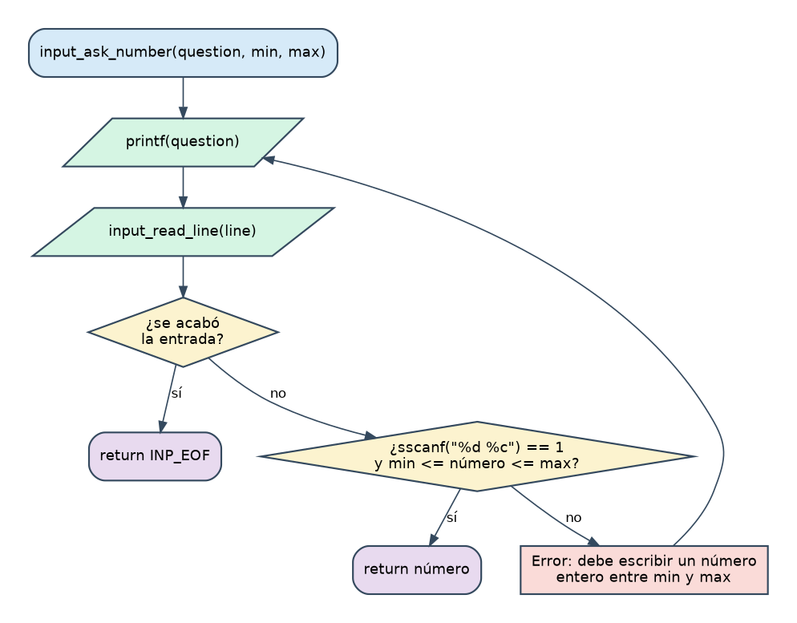

input_ask_number

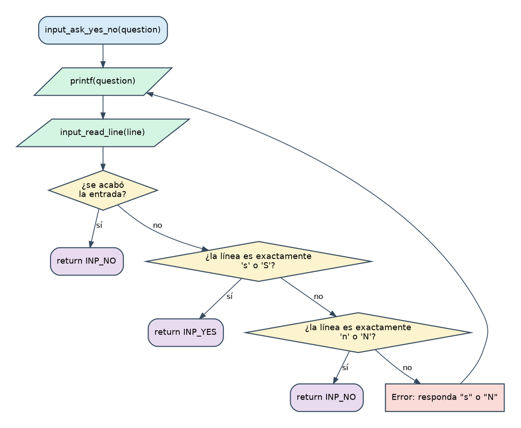

input_ask_yes_no

## 1.3 Ficha: lo que debes escribir

**`input.h`** (con guarda y todo documentado) declara:

| Elemento | Descripción |
| --- | --- |
| `INP_EOF` | Macro con valor `-1`: lo que devuelve `input_ask_number` si se acaba la entrada |
| `INP_NO`, `INP_YES` | Macros con valores `0` y `1` |
| `int input_read_line(char line[], int size)` | Lee una línea del teclado en `line`, **sin** el `\n`. Si era demasiado larga, descarta el resto. Devuelve **1** si leyó algo y **0** si se acabó la entrada |
| `int input_ask_number(const char question[], int min, int max)` | Muestra `question`; repite hasta que el usuario escribe **un único número entero** entre `min` y `max`. Si se acaba la entrada devuelve `INP_EOF` |
| `int input_ask_yes_no(const char question[])` | Muestra `question`; acepta `s`/`S` (→ `INP_YES`) y `n`/`N` (→ `INP_NO`) y **nada más** (ni líneas vacías). Si se acaba la entrada, devuelve `INP_NO` |

Cuando algo no es válido, escribe un mensaje de error claro y **vuelve a preguntar**.

**`input.c`** implementa las tres funciones. Necesitarás `#include <stdio.h>` y `<string.h>`, y una macro privada `INP_MAX_LINE` (80) para el tamaño de tus buffers.

**`test_input.c`**: un programa de prueba con su propio `main` que pide un número entre 1 y 21 y una respuesta sí/no, y los imprime. Los programas de prueba son una herramienta profesional: probar un módulo **aislado** antes de usarlo.

Compilar a mano (el `Makefile` llega en la Etapa 2):

```
gcc -Wall -o test_input test_input.c input.c
./test_input
```

## 1.4 Pistas (ábrelas en orden, solo si te atascas)

> **Pista 1.** `input_ask_number` y `input_ask_yes_no` tienen la misma forma: un bucle infinito (`while (1)`) que muestra la pregunta, lee una línea, y **si es válida hace `return`**; si no, muestra el error y el bucle da otra vuelta. Esto funciona porque `return` sale de la función aunque estés dentro del bucle.

> **Pista 2.** En `input_read_line`, tras `fgets`, mira el último carácter: `line[strlen(line) - 1]`. Si es `'\n'`, la línea cabía (bórralo). Si no, **o es una línea demasiado larga, o es la última línea del fichero sin `\n`**: en ambos casos, `getchar()` en bucle hasta `'\n'` o `EOF` es seguro.

> **Pista 3.** Para `sí/no` comprueba primero que `strlen(line) == 1` y después el carácter `line[0]`. Así `"si"` o `"nn"` no se aceptan.

## 1.5 Pruebas

Compila con `-Wall` (cero advertencias) y prueba cada fila de esta tabla con `test_input`:

| Escribes | Debe ocurrir |
| --- | --- |
| `abc` | Error y vuelve a preguntar (¡sin bucle infinito!) |
| *(solo Enter)* | Error y vuelve a preguntar |
| `0` y `22` | Error: fuera de 1-21 |
| `5 6` | Error |
| `12x` | Error |
| `7` | Acepta el 7 |
| `7` | Acepta el 7 |
| 300 letras `a` y Enter | **Un** solo error; y la siguiente lectura no se contamina con restos |
| **Ctrl+D** en cualquier pregunta | El programa termina sin colgarse |
| Sí/no: `x`, `si`, *(vacío)* | Error y repregunta |
| Sí/no: `s`, `S`, `n`, `N` | Aceptado |

> **Truco de profesional:** puedes probar sin teclear nada con una tubería: `printf 'abc\n\n7\ns\n' | ./test_input`.

## 1.6 Errores típicos

- `warning: implicit declaration of function 'strlen'` → te falta `#include <string.h>`.
- Usar `=` en vez de `==` dentro de un `if` (`-Wall` te avisa si te fijas).
- Olvidar que `char line[80]` cabe **79** letras, no 80.
- Leer con `fgets` pero olvidar quitar el `\n`: luego `"s\n"` no es igual a `"s"`.
- `scanf` “por si acaso” en alguna parte: **un solo** `scanf` en el programa puede romper tu buen trabajo con `fgets`. No lo uses.

## 1.7 Limitación conocida (para que la conozcas)

Si el usuario escribe un número gigantesco (`99999999999999999999`), el estándar de C dice que `sscanf("%d")` tiene comportamiento indefinido. En la práctica, en Linux con `glibc` el valor se satura y nuestra comprobación de rango lo rechaza (lo he probado), pero la solución *estrictamente* correcta usa la función `strtol`, que requiere punteros. Queda anotado para cuando los veamos.

## 1.8 Solución de referencia

Intenta tú primero. Después, compara con `etapa_1/` o con estos ficheros:

**Ver mi solución: input.h, input.c y test_input.c**

**`etapa_1/input.h`**

```c
#ifndef _INPUT_H_
#define _INPUT_H_

/* Valor que devuelve input_ask_number() cuando se acaba la entrada de datos */
#define INP_EOF (-1)

/* Respuesta negativa de input_ask_yes_no() */
#define INP_NO 0

/* Respuesta afirmativa de input_ask_yes_no() */
#define INP_YES 1

/* Lee una línea del teclado sin el salto de línea. Devuelve 0 si no hay */
int input_read_line(char line[], int size);

/* Pide un entero entre min y max (incluidos) hasta que el usuario acierta */
int input_ask_number(const char question[], int min, int max);

/* Hace una pregunta de tipo sí/no. Devuelve INP_YES o INP_NO */
int input_ask_yes_no(const char question[]);

#endif /* _INPUT_H_ */
```

**`etapa_1/input.c`**

```c
#include <stdio.h>
#include <string.h>
#include "input.h"

/* Tamaño máximo de una línea leída del teclado (incluye el '\0' final) */
#define INP_MAX_LINE 80

/*
 * input_read_line()
 * Lee una línea del teclado y la guarda en "line" sin el salto de línea.
 * Si el usuario escribe más de "size - 1" caracteres, el resto se descarta
 * para que no contamine la siguiente lectura.
 * Devuelve 1 si se leyó una línea y 0 si se acabó la entrada (EOF).
 */
int input_read_line(char line[], int size)
{
    int length;
    int character;

    if (fgets(line, size, stdin) == NULL)
    {
        return 0;
    }

    length = strlen(line);
    if (length > 0 && line[length - 1] == '\n')
    {
        line[length - 1] = '\0';
    }
    else
    {
        /* La línea no cabía entera: se tira lo que sobra hasta el '\n' */
        character = getchar();
        while (character != '\n' && character != EOF)
        {
            character = getchar();
        }
    }

    return 1;
}

/*
 * input_ask_number()
 * Muestra "question" y pide un número entero entre "min" y "max" (incluidos).
 * Repite la pregunta hasta que la línea contiene un único número válido.
 * Devuelve el número, o INP_EOF si se acaba la entrada (por eso "min" debe
 * ser mayor o igual que 0).
 */
int input_ask_number(const char question[], int min, int max)
{
    char line[INP_MAX_LINE];
    char extra;
    int number;

    while (1)
    {
        printf("%s", question);
        if (!input_read_line(line, INP_MAX_LINE))
        {
            return INP_EOF;
        }

        /* sscanf devuelve 1 solo si hay un número y nada más detrás */
        if (sscanf(line, "%d %c", &number, &extra) == 1
            && number >= min && number <= max)
        {
            return number;
        }

        printf("Error: debe escribir un número entero entre %d y %d.\n",
            min, max);
    }
}

/*
 * input_ask_yes_no()
 * Muestra "question" y espera "s" (sí) o "N" (no). También se aceptan "S" y
 * "n". Repite la pregunta hasta recibir una respuesta válida.
 * Devuelve INP_YES o INP_NO. Si se acaba la entrada, devuelve INP_NO.
 */
int input_ask_yes_no(const char question[])
{
    char line[INP_MAX_LINE];

    while (1)
    {
        printf("%s", question);
        if (!input_read_line(line, INP_MAX_LINE))
        {
            return INP_NO;
        }

        if (strlen(line) == 1 && (line[0] == 's' || line[0] == 'S'))
        {
            return INP_YES;
        }
        if (strlen(line) == 1 && (line[0] == 'n' || line[0] == 'N'))
        {
            return INP_NO;
        }

        printf("Error: responda \"s\" o \"N\".\n");
    }
}
```

**`etapa_1/test_input.c`**

```c
#include <stdio.h>
#include "input.h"

/*
 * main()
 * Programa de prueba del módulo input: pide un número y una respuesta sí/no.
 */
int main(void)
{
    int number;
    int answer;

    number = input_ask_number("Escriba un número entre 1 y 21: ", 1, 21);
    if (number == INP_EOF)
    {
        printf("\nSe acabó la entrada de datos.\n");
        return 0;
    }
    printf("Ha escrito el número %d\n", number);

    answer = input_ask_yes_no("¿Le gusta programar en C? [s/N]: ");
    if (answer == INP_YES)
    {
        printf("¡Estupendo!\n");
    }
    else
    {
        printf("Ya le gustará.\n");
    }

    return 0;
}
```

**Cosas para fijarte al comparar:** (1) cómo `input_read_line` distingue “línea cabe” de “línea larga” sin necesidad de punteros; (2) que `min` debe ser ≥ 0 porque `INP_EOF` es `-1` (y está documentado); (3) que los comentarios están **encima** de cada función; (4) que cada línea mide ≤ 80 caracteres y la sangría son tabuladores.

## 1.9 Recursos

- [`fgets`](https://en.cppreference.com/w/c/io/fgets) · [`sscanf` (documentada con `scanf`/`fscanf`)](https://en.cppreference.com/w/c/io/fscanf) · [`strlen`](https://en.cppreference.com/w/c/string/byte/strlen) · [`getchar`](https://en.cppreference.com/w/c/io/getchar)
- Beej’s Guide to C: capítulos sobre *Strings* y *Input/Output* en [beej.us/guide/bgc](https://beej.us/guide/bgc/)
- Por qué `scanf` da problemas: busca “scanf problems” o “fgets vs scanf” en cualquier guía de C; es un clásico.
- En el terminal: `man 3 fgets`, `man 3 sscanf`

## 1.10 Lista de comprobación

- `input.h` tiene guarda, prefijos `INP_` y todo documentado
- `gcc -Wall` sin una sola advertencia
- Todas las filas de la tabla de pruebas se comportan como se espera
- He reescrito `input_ask_number` **sin mirar** y funciona
- Sé explicar por qué `scanf` en un bucle puede ser infinito

# Etapa 2 · El menú principal, el bucle y `quit` (y tu primer `Makefile`)

> **Objetivo:** que el programa arranque, muestre el menú, lea una opción y permita salir con confirmación. El resto de opciones dirá “todavía no implementada”. **Dificultad:** media-baja. **Tiempo orientativo:** 1 sesión.

## 2.1 Teoría

### El bucle principal con una “bandera”

Un programa interactivo es: *mostrar menú → leer opción → ejecutarla → repetir* hasta que el usuario decida salir. Se escribe con un `while` controlado por una variable **bandera** (`exit_requested`):

```c
int exit_requested = 0;

while (!exit_requested)
{
    /* ... mostrar menú, leer opción, ejecutarla ... */
}
```

`!exit_requested` es “no `exit_requested`”: en C, `0` es falso y cualquier otro valor es verdadero.

### `switch`: elegir entre muchas opciones

Es un `if / else if` encadenado más legible cuando comparas **una misma variable** con valores constantes:

```c
switch (option)
{
    case MNU_QUIT:
        exit_requested = wificollector_quit();
        break;
    default:
        printf("Esa operación todavía no está implementada.\n");
        break;
}
```

> **Trampa clásica:** si olvidas el `break`, la ejecución **“se cae” al siguiente `case`** y ejecuta también su código (*fall-through*). `default` recoge todo lo que no coincide con ningún `case`.

### `enum`: ponerle nombre a los números

En vez de escribir `case 2:` (¿qué es el 2?), un `enum` da nombres a una serie de enteros:

```c
typedef enum
{
    MNU_QUIT = 1,   /* vale 1 */
    MNU_COLLECT,    /* vale 2: continúa contando */
    MNU_SHOW_DATA_ONE_NETWORK  /* vale 3 ... */
} menu_option_t;
```

Por defecto el primero vale 0; aquí lo forzamos a 1 para que el valor coincida con el número que ve el usuario en pantalla. Según la guía de estilo, los enumerados llevan prefijo del módulo (`MNU_`) y el tipo termina en `_t`.

### Funciones `static` y módulos

`print_menu()` solo la usa `main.c`, así que se declara `static`: **solo es visible dentro de ese fichero**. Es la regla E7: *todo lo que no necesiten los demás módulos, `static`*. Lo público (lo que sí usa `main.c`) se declara en `wificollector.h`.

### `Makefile`: que `make` compile por ti

Ya tienes cuatro `.c`. Escribir `gcc` a mano cada vez es pesado y propenso a errores. `make` lee un fichero `Makefile` con **reglas**:

```
objetivo: dependencias
<TAB>receta (el comando que lo construye)
```

- `make` ejecuta la **primera** regla por defecto. Por eso `main` debe ir la primera: así `make` a secas construye el programa.
- Solo rehace un objetivo si alguna dependencia es **más reciente** que él. Si cambias un solo `.c`, solo se recompila ese.
- ⚠️ **La receta debe empezar con un carácter TABULADOR**, no con espacios. El error `missing separator` casi siempre es esto.
- Variables: `CC = gcc` y `CFLAGS = -Wall -g` evitan repetir. `-g` incluye información para el depurador.
- `make clean` borra lo generado. Se marca `.PHONY` porque `clean` no es un fichero.

(Mira de nuevo el diagrama de la Etapa 0 sobre compilación por módulos.)

## 2.2 Diagrama de flujo

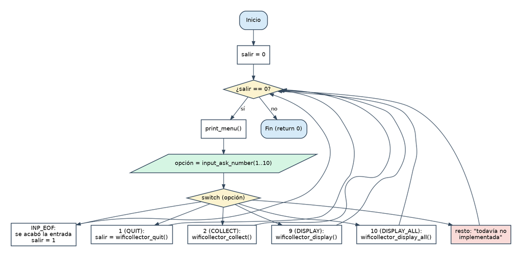

Bucle principal de main()

## 2.3 Ficha: lo que debes escribir

**`wificollector.h` / `wificollector.c`** (por ahora solo una función):

| Función | Descripción |
| --- | --- |
| `int wificollector_quit(void)` | Pregunta *“¿Está seguro de que desea salir del programa? [s/N]:”* con `input_ask_yes_no`. Si confirma, imprime una despedida y devuelve **1**; si no, devuelve **0** |

**`main.c`**:

- Un `enum menu_option_t` con las 10 operaciones del menú (el valor del primero debe ser 1).
- Una función `static void print_menu(void)` que imprime el menú **tal como aparece en el enunciado** (las 10 operaciones).
- `main()` con el bucle: imprime el menú, lee la opción con `input_ask_number(" Opción elegida: ", 1, 10)` y hace `switch`:
  - `INP_EOF` → avisar de que se acabó la entrada y salir (¡nunca bucle infinito!).
  - `MNU_QUIT` → `exit_requested = wificollector_quit();`
  - `default` → “Esa operación todavía no está implementada.”

**`Makefile`** con el objetivo `main` (el programa), `test_input` (el de la etapa anterior), una regla por cada `.o` indicando de qué `.c` y `.h` depende, y `clean`.

## 2.4 Pistas

> **Pista 1.** `case INP_EOF:` es válido aunque `INP_EOF` sea `-1`: los `case` aceptan cualquier constante entera, incluidas las macros.

> **Pista 2.** Cada `.o` depende de su `.c` **y de los `.h` que incluye**. Si cambias un `.h` y no lo pones como dependencia, `make` no recompilará lo que lo usa y tendrás errores incomprensibles.

> **Pista 3.** Si `make` dice `missing separator`, tu receta empieza por espacios. Si dice `undefined reference to 'wificollector_quit'`, falta incluir `wificollector.o` en la línea de enlace.

## 2.5 Pruebas

Compila con `make` (cero advertencias) y ejecuta `./main`:

| Escribes en el menú | Debe ocurrir |
| --- | --- |
| `abc`, vacío, `0`, `11`, `3 4` | Error y vuelve a pedir la opción |
| `3` (u otra no implementada) | “todavía no implementada” y vuelve el menú |
| `1`, luego `n` | Vuelve al menú |
| `1`, luego `x` o vacío | Error en la pregunta y repite |
| `1`, luego `s` | Despedida y el programa termina |
| **Ctrl+D** en el menú | “Fin de la entrada” y termina |

## 2.6 Solución de referencia

**Ver mi solución: main.c, wificollector.h, wificollector.c y Makefile**

**`etapa_2/main.c`**

```c
#include <stdio.h>
#include "input.h"
#include "wificollector.h"

/* Número de operaciones que muestra el menú principal */
#define MNU_NUM_OPTIONS 10

/*
 * menu_option_t
 * Operaciones del menú principal. El valor de cada una coincide con el número
 * que se muestra en pantalla (por eso la primera vale 1 y no 0).
 */
typedef enum
{
    MNU_QUIT = 1,
    MNU_COLLECT,
    MNU_SHOW_DATA_ONE_NETWORK,
    MNU_SELECT_BEST,
    MNU_DELETE_NET,
    MNU_SORT,
    MNU_EXPORT,
    MNU_IMPORT,
    MNU_DISPLAY,
    MNU_DISPLAY_ALL
} menu_option_t;

/*
 * print_menu()
 * Muestra por pantalla el menú principal con todas las operaciones.
 */
static void print_menu(void)
{
    printf("\n[2026] SAUCEM S.L. Recolector de redes inalámbricas\n\n");
    printf("    [ 1] wificollector_quit\n");
    printf("    [ 2] wificollector_collect\n");
    printf("    [ 3] wificollector_show_data_one_network\n");
    printf("    [ 4] wificollector_select_best\n");
    printf("    [ 5] wificollector_delete_net\n");
    printf("    [ 6] wificollector_sort\n");
    printf("    [ 7] wificollector_export\n");
    printf("    [ 8] wificollector_import\n");
    printf("    [ 9] wificollector_display\n");
    printf("    [10] wificollector_display_all\n\n");
}

/*
 * main()
 * Muestra el menú una y otra vez y ejecuta la operación elegida hasta que el
 * usuario confirma que quiere salir (o se acaba la entrada de datos).
 */
int main(void)
{
    int option;
    int exit_requested = 0;

    while (!exit_requested)
    {
        print_menu();
        option = input_ask_number("    Opción elegida: ", 1, MNU_NUM_OPTIONS);

        switch (option)
        {
            case INP_EOF:
                printf("\nFin de la entrada de datos.\n");
                exit_requested = 1;
                break;
            case MNU_QUIT:
                exit_requested = wificollector_quit();
                break;
            default:
                printf("Esa operación todavía no está implementada.\n");
                break;
        }
    }

    return 0;
}
```

**`etapa_2/wificollector.h`**

```c
#ifndef _WIFICOLLECTOR_H_
#define _WIFICOLLECTOR_H_

/* Pregunta si se quiere salir. Devuelve 1 si el usuario confirma, 0 si no */
int wificollector_quit(void);

#endif /* _WIFICOLLECTOR_H_ */
```

**`etapa_2/wificollector.c`**

```c
#include <stdio.h>
#include "wificollector.h"
#include "input.h"

/*
 * wificollector_quit()
 * Pregunta al usuario si de verdad quiere salir del programa.
 * Devuelve 1 si el usuario confirma y 0 si decide seguir.
 */
int wificollector_quit(void)
{
    int answer;

    answer = input_ask_yes_no(
        "¿Está seguro de que desea salir del programa? [s/N]: ");

    if (answer == INP_YES)
    {
        printf("¡Hasta pronto!\n");
        return 1;
    }

    return 0;
}
```

**`etapa_2/Makefile`**

```
# Makefile - Etapa 2: menú principal y wificollector_quit
# Compilar:  make        Ejecutar:  ./main        Limpiar:  make clean

CC = gcc
CFLAGS = -Wall -g

main: main.o input.o wificollector.o
    $(CC) $(CFLAGS) -o main main.o input.o wificollector.o

test_input: test_input.o input.o
    $(CC) $(CFLAGS) -o test_input test_input.o input.o

main.o: main.c input.h wificollector.h
    $(CC) $(CFLAGS) -c main.c

input.o: input.c input.h
    $(CC) $(CFLAGS) -c input.c

wificollector.o: wificollector.c wificollector.h input.h
    $(CC) $(CFLAGS) -c wificollector.c

test_input.o: test_input.c input.h
    $(CC) $(CFLAGS) -c test_input.c

clean:
    rm -f *.o main test_input

.PHONY: clean
```

**Fíjate en:** que `wificollector_quit` **no** termina el programa: solo devuelve “sí/no” y es `main` quien decide. Así cada función hace una sola cosa y es fácil de probar.

## 2.7 Recursos

- [`switch`](https://en.cppreference.com/w/c/language/switch) · [`enum`](https://en.cppreference.com/w/c/language/enum)
- [Manual de GNU Make](https://www.gnu.org/software/make/manual/make.html) (completo) y [Makefile Tutorial](https://makefiletutorial.com/) (corto y práctico)
- Beej’s Guide to C: capítulos sobre `switch`, `enum` y *Multifile Projects*

## 2.8 Lista de comprobación

- `make` compila sin advertencias y `make clean` limpia
- Todas las filas de la tabla de pruebas funcionan
- Sé explicar qué pasa si quito un `break` de un `case`
- Sé explicar por qué `print_menu` es `static`
- He reescrito `main()` sin mirar

# Etapa 3 · La estructura `wifi_cell` y cómo mostrar una celda

> **Objetivo:** definir el tipo de dato que representa un punto de acceso y escribir la función que lo imprime con el formato del enunciado. **Dificultad:** baja-media. **Tiempo orientativo:** 1 sesión.

## 3.1 Teoría

### `struct`: agrupar datos relacionados

Un punto de acceso tiene 9 datos (número de celda, MAC, ESSID…). En vez de manejar 9 variables sueltas, una `struct` los agrupa en **un solo tipo nuevo**:

```c
struct wifi_cell
{
    int cell_id;
    char address[CEL_MAX_STR];
    /* ... más campos ... */
};
```

Esto solo **define el tipo** (como un molde). Para tener un dato real declaras una variable de ese tipo y accedes a sus campos con el punto:

```c
struct wifi_cell cell;     /* una variable de tipo struct wifi_cell */
cell.cell_id = 1;          /* acceso a un campo con '.' */
```

### Elegir el tipo de cada campo

| Dato | Ejemplo | Tipo | Por qué |
| --- | --- | --- | --- |
| Identificador de celda | `1` | `int` | Número natural |
| Dirección MAC | `00:01:38:1F:CB:3E` | `char[80]` | Texto (con `:`) |
| ESSID | `PTNET` | `char[80]` | Texto, sin las comillas del fichero |
| Modo | `Master` | `char[80]` | Texto (sencillo; un `enum` sería una mejora posterior) |
| Canal | `2` | `int` | Número natural |
| Cifrado | `on` / `off` | `char[80]` | Texto |
| Calidad `n1/n2` | `70/70` | `int` + `int` | **Dos** números: `quality` y `quality_max` |
| Frecuencia | `2.417` | `double` | Tiene decimales. `double` tiene más precisión que `float` |
| Nivel de señal | `-33` | `int` | Entero negativo (dBm) |

El enunciado exige cadenas de **80 caracteres máximo**, así que usamos una macro `CEL_MAX_STR` = 80 para todas (regla C1 de la guía: tamaños con macros, y prefijo `CEL_` por ser constante pública del módulo `cell`).

### Las cadenas no se asignan con `=`

```c
cell.essid = "PTNET";           /* ERROR: no se puede asignar a un array */
strcpy(cell.essid, "PTNET");    /* CORRECTO: copia carácter a carácter (<string.h>) */
```

`strcpy` **no comprueba** que quepa: si el origen es más largo que el destino, escribe fuera del array (desbordamiento). En la Etapa 4 evitaremos ese riesgo usando `sscanf` con límite de anchura.

### Copiar y pasar structs

- **Una `struct` se copia entera con `=`**, incluidos los arrays que lleva dentro: `cells[3] = cell;` copia 352 bytes. (Los arrays sueltos, en cambio, no se pueden copiar así.)
- Al pasar una `struct` a una función **se pasa una copia** (*paso por valor*): `void cell_print(struct wifi_cell cell)`. La función no puede modificar el original, y eso es justo lo que queremos al imprimir. Copiar 352 bytes es barato aquí; cuando veas punteros aprenderás a pasar solo la dirección.

### Un array de structs en memoria

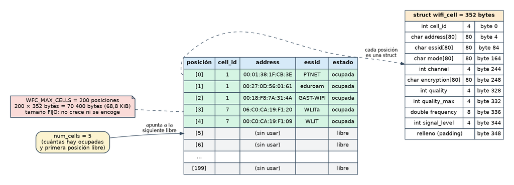

Array de 200 posiciones y estructura de una celda

Cada posición del array es una `struct wifi_cell` completa (352 bytes: la suma de los campos más algo de **relleno** para alinear el `double`). El array global de 200 ocupa unos **68,8 KiB** y su tamaño es **fijo**: eso es lo que cambiará en la Entrega 2. Fíjate también en que `num_cells` sirve a la vez de **contador** (cuántas hay) y de **índice de la primera posición libre**. Lo usaremos en la Etapa 5.

### `printf` con formato

| Formato | Para | Ejemplo en nuestro caso |
| --- | --- | --- |
| `%d` | `int` | `cell.channel` |
| `%s` | cadena | `cell.essid` |
| `%f` | `double` (6 decimales) | `2.417` se imprime `2.417000` |
| `\"` | comilla doble dentro de una cadena | `"\"%s\""` imprime `"PTNET"` |

El enunciado muestra este formato de salida (y nuestro programa debe reproducirlo):

```
Cell 1: 00:01:38:1F:CB:3E "PTNET" Master 2 on 70/70 2.417000 -33
```

## 3.2 Ficha: lo que debes escribir

**`cell.h`**:

- Guarda `_CELL_H_`.
- La macro `CEL_MAX_STR` (80).
- La `struct wifi_cell` con los 9 datos (10 campos, porque la calidad son dos), **cada campo comentado**.
- El prototipo `void cell_print(struct wifi_cell cell);`

**`cell.c`**: la función `cell_print`, que imprime la celda en **una línea** con el formato de arriba.

**`test_cell_print.c`**: un `main` que rellena **a mano** una celda (con `strcpy` para las cadenas) con los datos de la celda 1 del enunciado y la imprime.

Para compilar a mano: `gcc -Wall -o test_cell_print test_cell_print.c cell.c`

## 3.3 Pruebas

La salida de `test_cell_print` debe ser **exactamente**:

```
Cell 1: 00:01:38:1F:CB:3E "PTNET" Master 2 on 70/70 2.417000 -33
```

Cambia valores (otro canal, otro nivel de señal, una frecuencia de `5.2`) y comprueba que el formato sigue siendo correcto.

## 3.4 Errores típicos

- `%d` con un `double` (o `%f` con un `int`): `-Wall` avisa con `format '%d' expects argument of type 'int'`. **Léelo**: te dice exactamente cuál es el error.
- Olvidar `#include <string.h>` en el test (por usar `strcpy`).
- Poner el `;` tras la `}` de la `struct` en el `.h` (es obligatorio: `};`).
- Declarar `cell_print` en el `.h` con un tipo y definirla en el `.c` con otro: por eso la regla E3 manda incluir el propio `.h` en el `.c`: así el compilador detecta la discrepancia.

## 3.5 Solución de referencia

**Ver mi solución: cell.h, cell.c y test_cell_print.c**

**`etapa_3/cell.h`**

```c
#ifndef _CELL_H_
#define _CELL_H_

/* Tamaño máximo de las cadenas de texto de una celda (incluye el '\0') */
#define CEL_MAX_STR 80

/*
 * struct wifi_cell
 * Datos de un punto de acceso: un bloque de un fichero info_cell_N.txt.
 */
struct wifi_cell
{
    int cell_id;                 /* Identificador de celda (la N de "Cell N") */
    char address[CEL_MAX_STR];   /* Dirección MAC, p. ej. 00:01:38:1F:CB:3E */
    char essid[CEL_MAX_STR];     /* Nombre de la red, sin las comillas */
    char mode[CEL_MAX_STR];      /* Modo: Master, Ad-Hoc, Managed... */
    int channel;                 /* Canal */
    char encryption[CEL_MAX_STR];/* Cifrado: "on" u "off" */
    int quality;                 /* Calidad actual (el n1 de n1/n2) */
    int quality_max;             /* Calidad máxima (el n2 de n1/n2) */
    double frequency;            /* Frecuencia en GHz */
    int signal_level;            /* Nivel de señal en dBm */
};

/* Imprime una celda en una línea: Cell 1: <MAC> "<ESSID>" <modo> ... */
void cell_print(struct wifi_cell cell);

#endif /* _CELL_H_ */
```

**`etapa_3/cell.c`**

```c
#include <stdio.h>
#include "cell.h"

/*
 * cell_print()
 * Imprime una celda en una sola línea. Ejemplo de salida:
 * Cell 1: 00:01:38:1F:CB:3E "PTNET" Master 2 on 70/70 2.417000 -33
 */
void cell_print(struct wifi_cell cell)
{
    printf("Cell %d: %s \"%s\" %s %d %s %d/%d %f %d\n",
        cell.cell_id, cell.address, cell.essid, cell.mode, cell.channel,
        cell.encryption, cell.quality, cell.quality_max, cell.frequency,
        cell.signal_level);
}
```

**`etapa_3/test_cell_print.c`**

```c
#include <stdio.h>
#include <string.h>
#include "cell.h"

/*
 * main()
 * Programa de prueba de cell_print(): rellena una celda a mano y la imprime.
 * Debe imprimir exactamente:
 * Cell 1: 00:01:38:1F:CB:3E "PTNET" Master 2 on 70/70 2.417000 -33
 */
int main(void)
{
    struct wifi_cell cell;

    cell.cell_id = 1;
    strcpy(cell.address, "00:01:38:1F:CB:3E");
    strcpy(cell.essid, "PTNET");
    strcpy(cell.mode, "Master");
    cell.channel = 2;
    strcpy(cell.encryption, "on");
    cell.quality = 70;
    cell.quality_max = 70;
    cell.frequency = 2.417;
    cell.signal_level = -33;

    cell_print(cell);

    return 0;
}
```

## 3.6 Recursos

- [`struct`](https://en.cppreference.com/w/c/language/struct) · [`strcpy`](https://en.cppreference.com/w/c/string/byte/strcpy) · [`printf` y sus formatos](https://en.cppreference.com/w/c/io/fprintf)
- Beej’s Guide to C: capítulo *Structs*
- `man 3 printf`

## 3.7 Lista de comprobación

- La salida es idéntica a la del enunciado, incluidos `2.417000` y las comillas del ESSID
- Todos los campos de la `struct` están comentados
- Sé explicar por qué `strcpy` es peligroso y por qué `cell.essid = "x"` no compila
- Sé qué significa “paso por valor”
- He reescrito `cell_print` sin mirar

# Etapa 4 · Leer un bloque de un fichero de texto

> **Objetivo:** convertir las 9 líneas de un bloque de `info_cell_N.txt` en una `struct wifi_cell`, detectando ficheros vacíos, truncados o con formato incorrecto. **Dificultad:** **la más alta de la Fase 1.** Tómate el tiempo. **Tiempo orientativo:** 2 sesiones.

## 4.1 Teoría

### Ficheros de texto en C

```c
FILE *file;                      /* "manillar" del fichero abierto */
file = fopen("info_cell_1.txt", "r");   /* "r" = leer */
if (file == NULL)                /* ¡SIEMPRE comprobar! */
{
    /* no existe, sin permisos, etc. */
}
/* ... leer con fgets(buffer, size, file) ... */
fclose(file);                    /* cerrar siempre que se abrió */
```

- `fopen` devuelve `NULL` si falla. **Si no lo compruebas y sigues, tu programa se cae.** El enunciado pide expresamente robustez ante “un nombre de fichero incorrecto”.
- `fgets` funciona igual que con el teclado, pero leyendo de `file` en vez de `stdin`: devuelve `NULL` cuando no quedan más líneas.
- Cada `fopen` exitoso debe tener su `fclose`.

### Estrategia: leer las 9 líneas, y después analizarlas

Un bloque son siempre 9 líneas en el mismo orden. Dividimos el trabajo en dos pasos:

1. **Leer** las 9 líneas con `fgets` y guardarlas en un array de 9 cadenas.
2. **Analizar** cada línea con un `sscanf` que sabe *cómo es esa línea*.

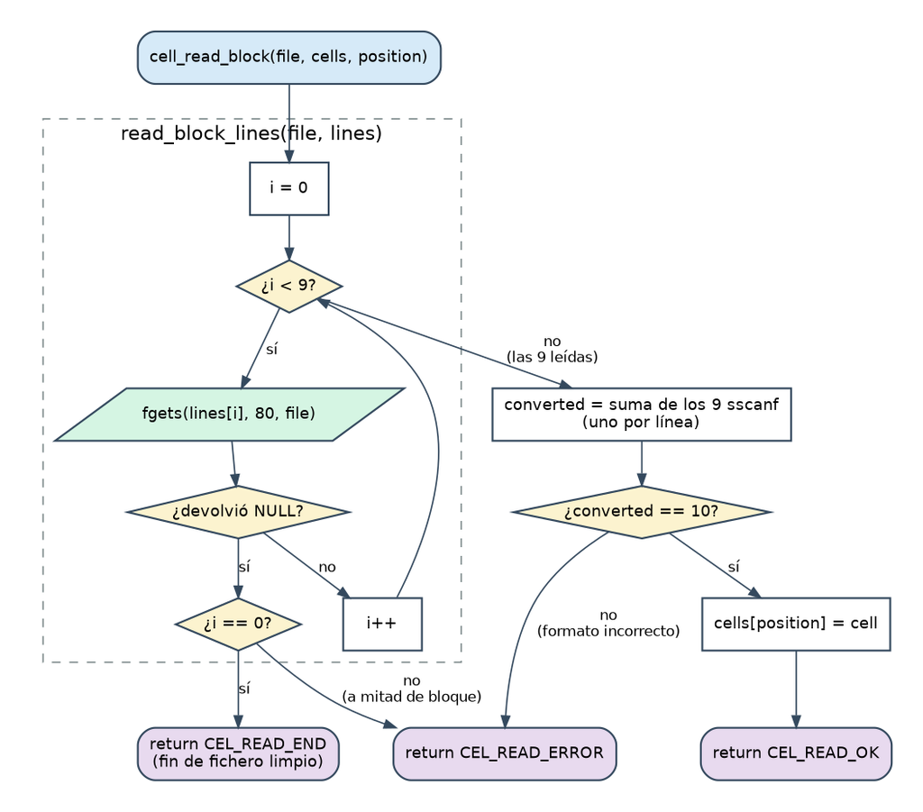

cell_read_block: leer 9 líneas y analizarlas

Un array de 9 cadenas de 80 caracteres es un **array de dos dimensiones**:

```c
char lines[9][80];     /* lines[0] es la línea 1 ... lines[8] la novena */
```

Al pasarlo a una función, solo puede omitirse la **primera** dimensión: `char lines[][CEL_MAX_STR]`.

### Los `sscanf` de este proyecto, uno por línea

En el formato de `sscanf`, el texto literal **debe coincidir exactamente** con la línea, y cada `%` extrae un dato:

| Línea del fichero | Campo(s) | Formato de `sscanf` | Datos |
| --- | --- | --- | --- |
| `Cell 1` | `cell_id` | `"Cell %d"` | 1 |
| `Address: 00:01:38:1F:CB:3E` | `address` | `"Address: %79s"` | 1 |
| `ESSID:"PTNET"` | `essid` | `"ESSID:\"%79[^\"]\""` | 1 |
| `Mode:Master` | `mode` | `"Mode:%79s"` | 1 |
| `Channel:2` | `channel` | `"Channel:%d"` | 1 |
| `Encryption key:on` | `encryption` | `"Encryption key:%79s"` | 1 |
| `Quality=70/70` | `quality`, `quality_max` | `"Quality=%d/%d"` | **2** |
| `Frequency:2.417 GHz` | `frequency` | `"Frequency:%lf"` | 1 |
| `Signal level=-33 dBm` | `signal_level` | `"Signal level=%d"` | 1 |
|  |  | **Total esperado** | **10** |

Tres detalles importantes:

1. **`%79s` y no `%s`.** El número es la **anchura máxima**: `sscanf` copiará como mucho 79 caracteres y añadirá el `'\0'`, así que **nunca desborda** un `char[80]`. Siempre `tamaño - 1`.
2. **`%[^"]` (un *scanset*)** significa “lee todos los caracteres hasta encontrar una comilla”. Es necesario porque `%s` se detiene en el **primer espacio**, y hay ESSID como `"Miguel 3"`. Fíjate cómo las comillas literales del formato (escritas `\"`) delimitan el nombre.
3. **`%lf` para leer un `double`** con `sscanf` (`l` de *long*). En `printf`, en cambio, se usa `%f` para `double`.

### Comprobar que todo salió bien: sumar lo que devuelve `sscanf`

Cada `sscanf` devuelve cuántos datos convirtió. Si **la suma de los nueve es 10**, todo el bloque era correcto. Si una línea tiene la palabra clave equivocada (`Canal:` en vez de `Channel:`) o falta un dato, esa llamada devuelve menos (0 o -1) y la suma no llega a 10.

### Devolver un estado con un `enum`

La función puede terminar de tres formas distintas, y al que la llama le interesa saber cuál:

```c
typedef enum
{
    CEL_READ_OK,     /* se leyó un bloque completo y correcto */
    CEL_READ_END,    /* no quedan bloques: fin del fichero (normal) */
    CEL_READ_ERROR   /* bloque incompleto o con formato erróneo */
} cell_read_status_t;
```

Distinguir `END` de `ERROR` es lo que permite decir “fichero vacío” o “fichero truncado” en vez de un genérico “algo falló”.

### Rellenar primero una variable local

`cell_read_block` analiza los datos en una `struct wifi_cell` **local** y **solo si todo es correcto** la copia al array con `cells[position] = cell;`. Así, un bloque a medias nunca deja “basura” en el array global.

### Qué pasa si no limitas la anchura (desbordamiento de buffer)

Si el ESSID de un fichero tuviera 200 caracteres y usaras `%s`, `sscanf` escribiría 200 bytes en un array de 80, **pisando otras variables en memoria**. Es el fallo de seguridad más típico de C. Con `%79s`, el mismo fichero haría que el campo se rellene con los 79 primeros caracteres y el programa siga siendo seguro.

## 4.2 Ficha: lo que debes escribir

Amplía `cell.h` y `cell.c`:

**En `cell.h`**: `#include <stdio.h>` (por el tipo `FILE`), el `enum cell_read_status_t` y el prototipo:

```c
cell_read_status_t cell_read_block(FILE *file, struct wifi_cell cells[],
    int position);
```

**En `cell.c`**:

| Elemento | Descripción |
| --- | --- |
| Macros privadas | `CEL_LINES_PER_BLOCK` (9) y `CEL_FIELDS_PER_BLOCK` (10) |
| `static cell_read_status_t read_block_lines(FILE *file, char lines[][CEL_MAX_STR])` | Lee las 9 líneas con `fgets`. Devuelve `CEL_READ_END` si el fichero se acaba **antes de la primera línea**, `CEL_READ_ERROR` si se acaba **a mitad de bloque** y `CEL_READ_OK` si las leyó todas |
| `cell_read_status_t cell_read_block(...)` | Lee las líneas, hace los 9 `sscanf`, comprueba que suman 10 y, si es así, guarda la celda en `cells[position]`. **No** comprueba que `position` sea válida: es responsabilidad de quien llama |

**`test_cell_read.c`**: abre `info_cell_1.txt`, llama a `cell_read_block` en un bucle hasta que no devuelva `CEL_READ_OK`, imprime cada celda y al final dice cuántos bloques leyó (debe ser 3).

Compilar: `gcc -Wall -o test_cell_read test_cell_read.c cell.c` (con los ficheros de datos en la misma carpeta).

## 4.3 Pistas

> **Pista 1.** Estructura de `cell_read_block`: (1) `status = read_block_lines(...)`; si no es `OK`, `return status;`. (2) Los nueve `sscanf`, el primero con `converted = ...` y los demás con `converted += ...`. (3) `if (converted != CEL_FIELDS_PER_BLOCK) return CEL_READ_ERROR;`. (4) copiar y `return CEL_READ_OK;`.

> **Pista 2.** Para los campos de texto, pasa el nombre del array **sin `&`** (`cell.address`); para los números, **con `&`** (`&cell.channel`). Un array ya “es” una dirección; un `int` no.

> **Pista 3.** En `read_block_lines`, si `fgets` falla en la vuelta `i == 0`, el fichero acabó limpiamente; si falla en cualquier otra, el bloque estaba incompleto.

## 4.4 Pruebas

1. Ejecuta `test_cell_read`: debe imprimir las 3 celdas del fichero 1 y `Bloques leídos: 3`.
2. **Ahora rómpelo tú** (copia el fichero y modifícalo, sin tocar los originales):

| Modificación | Resultado esperado |
| --- | --- |
| Fichero vacío | 0 bloques, sin error |
| Borrar las últimas 3 líneas del fichero | Lee los bloques completos y luego `CEL_READ_ERROR` |
| Cambiar `Channel:` por `Canal:` en un bloque | `CEL_READ_ERROR` en ese bloque |
| Nombre de fichero inexistente | El test avisa de que no se pudo abrir (`fopen` devolvió `NULL`) |
| Un ESSID con espacio (`info_cell_6.txt`: `"Miguel 3"`) | Se lee entero, con el espacio |

Comprobar que tu código **se comporta bien ante datos malos** es, precisamente, lo que significa ser robusto.

## 4.5 Errores típicos

- Olvidar el `&` en `sscanf` para los `int`/`double` → comportamiento indefinido (`-Wall` suele avisar).
- Usar `%s` para el ESSID: se corta en `"Miguel`.
- Escribir `%79s` pero declarar el array de 50: el límite debe ser **tamaño − 1**.
- Usar `%f` en vez de `%lf` en `sscanf` para un `double`: guarda basura sin avisar.
- Dejar el fichero abierto al hacer `return` anticipado (fuga de recursos).

## 4.6 Retos opcionales (para practicar sin ayuda)

- **Reto A:** haz que el análisis no dependa del **orden** de las líneas: mira el principio de cada línea con `strncmp` y decide qué `sscanf` aplicar.
- **Reto B:** valida que la MAC tiene el formato `XX:XX:XX:XX:XX:XX`.
- **Reto C:** convierte `mode` en un `enum` (`Auto`, `Ad-Hoc`, `Managed`, `Master`, `Repeater`, `Secondary`, `Monitor`, `Unknown`).

## 4.7 Solución de referencia

**Ver mi solución: cell.h, cell.c y test_cell_read.c**

**`etapa_4/cell.h`**

```c
#ifndef _CELL_H_
#define _CELL_H_

#include <stdio.h>

/* Tamaño máximo de las cadenas de texto de una celda (incluye el '\0') */
#define CEL_MAX_STR 80

/*
 * struct wifi_cell
 * Datos de un punto de acceso: un bloque de un fichero info_cell_N.txt.
 */
struct wifi_cell
{
    int cell_id;                 /* Identificador de celda (la N de "Cell N") */
    char address[CEL_MAX_STR];   /* Dirección MAC, p. ej. 00:01:38:1F:CB:3E */
    char essid[CEL_MAX_STR];     /* Nombre de la red, sin las comillas */
    char mode[CEL_MAX_STR];      /* Modo: Master, Ad-Hoc, Managed... */
    int channel;                 /* Canal */
    char encryption[CEL_MAX_STR];/* Cifrado: "on" u "off" */
    int quality;                 /* Calidad actual (el n1 de n1/n2) */
    int quality_max;             /* Calidad máxima (el n2 de n1/n2) */
    double frequency;            /* Frecuencia en GHz */
    int signal_level;            /* Nivel de señal en dBm */
};

/*
 * cell_read_status_t
 * Resultado de intentar leer un bloque de un fichero.
 */
typedef enum
{
    CEL_READ_OK,    /* Se leyó un bloque completo y correcto */
    CEL_READ_END,   /* No quedan más bloques: fin del fichero */
    CEL_READ_ERROR  /* El bloque está incompleto o tiene mal formato */
} cell_read_status_t;

/* Imprime una celda en una línea: Cell 1: <MAC> "<ESSID>" <modo> ... */
void cell_print(struct wifi_cell cell);

/* Lee el siguiente bloque del fichero y lo guarda en cells[position] */
cell_read_status_t cell_read_block(FILE *file, struct wifi_cell cells[],
    int position);

#endif /* _CELL_H_ */
```

**`etapa_4/cell.c`**

```c
#include <stdio.h>
#include "cell.h"

/* Número de líneas de texto que ocupa un bloque en un fichero info_cell */
#define CEL_LINES_PER_BLOCK 9

/* Datos que sscanf debe convertir en total por bloque ("n1/n2" cuenta 2) */
#define CEL_FIELDS_PER_BLOCK 10

/*
 * cell_print()
 * Imprime una celda en una sola línea. Ejemplo de salida:
 * Cell 1: 00:01:38:1F:CB:3E "PTNET" Master 2 on 70/70 2.417000 -33
 */
void cell_print(struct wifi_cell cell)
{
    printf("Cell %d: %s \"%s\" %s %d %s %d/%d %f %d\n",
        cell.cell_id, cell.address, cell.essid, cell.mode, cell.channel,
        cell.encryption, cell.quality, cell.quality_max, cell.frequency,
        cell.signal_level);
}

/*
 * read_block_lines()
 * Lee del fichero las 9 líneas de un bloque y las guarda en "lines".
 * Devuelve CEL_READ_OK si las leyó todas, CEL_READ_END si el fichero ya
 * estaba acabado antes de la primera línea y CEL_READ_ERROR si se acaba a
 * mitad de un bloque.
 */
static cell_read_status_t read_block_lines(FILE *file,
    char lines[][CEL_MAX_STR])
{
    int i;

    for (i = 0; i < CEL_LINES_PER_BLOCK; i++)
    {
        if (fgets(lines[i], CEL_MAX_STR, file) == NULL)
        {
            if (i == 0)
            {
                return CEL_READ_END;
            }
            return CEL_READ_ERROR;
        }
    }

    return CEL_READ_OK;
}

/*
 * cell_read_block()
 * Lee el siguiente bloque de 9 líneas del fichero ya abierto "file" y, si es
 * correcto, lo guarda en cells[position]. El que llama debe asegurarse de que
 * "position" es una posición válida del array.
 * Devuelve CEL_READ_OK, CEL_READ_END (no quedan bloques) o CEL_READ_ERROR.
 */
cell_read_status_t cell_read_block(FILE *file, struct wifi_cell cells[],
    int position)
{
    char lines[CEL_LINES_PER_BLOCK][CEL_MAX_STR];
    struct wifi_cell cell;
    cell_read_status_t status;
    int converted;

    status = read_block_lines(file, lines);
    if (status != CEL_READ_OK)
    {
        return status;
    }

    /* Cada sscanf devuelve cuántos datos pudo convertir de su línea */
    converted = sscanf(lines[0], "Cell %d", &cell.cell_id);
    converted += sscanf(lines[1], "Address: %79s", cell.address);
    converted += sscanf(lines[2], "ESSID:\"%79[^\"]\"", cell.essid);
    converted += sscanf(lines[3], "Mode:%79s", cell.mode);
    converted += sscanf(lines[4], "Channel:%d", &cell.channel);
    converted += sscanf(lines[5], "Encryption key:%79s", cell.encryption);
    converted += sscanf(lines[6], "Quality=%d/%d", &cell.quality,
        &cell.quality_max);
    converted += sscanf(lines[7], "Frequency:%lf", &cell.frequency);
    converted += sscanf(lines[8], "Signal level=%d", &cell.signal_level);

    if (converted != CEL_FIELDS_PER_BLOCK)
    {
        return CEL_READ_ERROR;
    }

    cells[position] = cell;
    return CEL_READ_OK;
}
```

**`etapa_4/test_cell_read.c`**

```c
#include <stdio.h>
#include "cell.h"

/* Capacidad del array de prueba */
#define TST_MAX_CELLS 10

/*
 * main()
 * Programa de prueba de cell_read_block(): lee todos los bloques del fichero
 * info_cell_1.txt, los imprime y cuenta cuántos hay.
 */
int main(void)
{
    struct wifi_cell cells[TST_MAX_CELLS];
    cell_read_status_t status;
    FILE *file;
    int count = 0;

    file = fopen("info_cell_1.txt", "r");
    if (file == NULL)
    {
        printf("Error: no se pudo abrir info_cell_1.txt\n");
        return 1;
    }

    status = CEL_READ_OK;
    while (status == CEL_READ_OK && count < TST_MAX_CELLS)
    {
        status = cell_read_block(file, cells, count);
        if (status == CEL_READ_OK)
        {
            cell_print(cells[count]);
            count++;
        }
    }

    if (status == CEL_READ_ERROR)
    {
        printf("Error: formato incorrecto en el fichero\n");
    }
    printf("Bloques leídos: %d\n", count);

    fclose(file);
    return 0;
}
```

**Fíjate en:** el mensaje del comentario de cada `sscanf`, el reparto en dos funciones para que ninguna sea larga (regla B4) y que `read_block_lines` es `static` (solo la usa este fichero).

## 4.8 Recursos

- [`fopen`](https://en.cppreference.com/w/c/io/fopen) · [`fgets`](https://en.cppreference.com/w/c/io/fgets) · [`sscanf` y sus formatos (anchura, `%[...]`)](https://en.cppreference.com/w/c/io/fscanf)
- Beej’s Guide to C: capítulos *File Input/Output* y *Multidimensional Arrays*
- Buscar: “buffer overflow C scanf %s width” para entender por qué el límite de anchura importa.
- `man 3 fopen`, `man 3 sscanf`

## 4.9 Lista de comprobación

- `test_cell_read` lee 3 bloques del fichero 1
- Los casos “rotos” de la tabla dan el resultado esperado
- Sé explicar `%79s`, `%[^"]` y por qué se suma hasta 10
- Sé explicar por qué se rellena una variable local y no directamente el array
- He reescrito `cell_read_block` **sin mirar**

# Etapa 5 · `wificollector_collect`: llenar el array

> **Objetivo:** que la opción 2 del menú pida una celda, lea su fichero, añada sus puntos de acceso a un array de 200 posiciones y pregunte si se quiere añadir otra. **Dificultad:** media (ya tienes casi todas las piezas). **Tiempo orientativo:** 1-2 sesiones.

## 5.1 Teoría

### Estado dentro de un módulo: variables globales `static`

El array y su contador tienen que **sobrevivir** entre una opción del menú y la siguiente (recolectas hoy, muestras después). Eso se consigue con variables **globales**, declaradas fuera de cualquier función. Reglas de la guía de estilo (E7):

- Las globales privadas son `static`: solo se ven desde este `.c`. Nadie de fuera puede modificarlas por error; todo acceso pasa por tus funciones.
- Se declaran **juntas, al principio del fichero**, nunca desperdigadas.
- Se documentan.

```c
/* Array con los puntos de acceso recolectados hasta el momento */
static struct wifi_cell cells[WFC_MAX_CELLS];

/* Número de posiciones del array que están ocupadas */
static int num_cells = 0;
```

### La regla que no se puede romper: los límites del array

Un array de 200 elementos tiene posiciones válidas **0 a 199**. C **no comprueba** los límites: escribir en `cells[200]` no da error; escribe en la memoria de al lado y estropea otra cosa (*comportamiento indefinido*), y el fallo puede aparecer mucho después y en otro sitio. **Eres tú quien debe comprobarlo antes de escribir:**

```c
while (status == CEL_READ_OK && num_cells < WFC_MAX_CELLS)
```

`num_cells` cumple siempre dos papeles a la vez (mira el diagrama de memoria de la Etapa 3):

- **Cuántas** posiciones hay ocupadas.
- El **índice de la primera libre** (si hay 5 ocupadas, son la 0-4 y la siguiente libre es la 5).

Por eso se escribe en `cells[num_cells]` y *después* se hace `num_cells++`.

### No confundir dos números

| Nombre | Qué es | Rango |
| --- | --- | --- |
| `cell_id` | El **número de celda** que escribe el usuario; el `N` de `info_cell_N.txt` y el campo `cell_id` de cada punto de acceso | 1-21 |
| posición (`position`, `num_cells`) | Un **índice del array** | 0-199 |

Una celda (`cell_id`) tiene varios puntos de acceso, cada uno en una posición distinta del array.

### `snprintf`: construir un nombre de fichero

```c
char file_name[WFC_MAX_FILE_NAME];
snprintf(file_name, WFC_MAX_FILE_NAME, "info_cell_%d.txt", cell_id);
```

Es `printf`, pero **escribe en una cadena** en vez de en pantalla, y el segundo parámetro es el tamaño máximo, así que **nunca desborda**. (`sprintf`, sin tamaño, sí puede: evítalo.)

### Descomponer en funciones pequeñas

Tres funciones, cada una con una única responsabilidad (regla B4: que quepan en pantalla):

| Función | Visibilidad | Responsabilidad |
| --- | --- | --- |
| `wificollector_collect` | pública | El bucle “¿qué celda? → leer → ¿otra?” |
| `collect_one_cell` | `static` | Abrir **un** fichero y añadir todos sus bloques |
| `print_added_cell` | `static` | Imprimir el mensaje de “añadido” y la celda |

### El bucle de lectura y por qué hay que cerrar el fichero

El bucle de `collect_one_cell` termina por tres motivos distintos (se acabó el fichero, bloque defectuoso, array lleno). Después de él **siempre** se hace `fclose(file)` y luego se decide qué mensaje dar mirando cómo terminó (`status`). Esto es más limpio que ir cerrando el fichero en cada rama de error.

### Cadenas largas partidas en varias líneas

C pega automáticamente los literales de texto adyacentes, así que puedes cumplir la regla de las 80 columnas sin perder nada:

```c
printf("Aviso: el array está lleno (%d posiciones). No se añaden "
    "más datos.\n\n", WFC_MAX_CELLS);
```

## 5.2 Diagramas de flujo

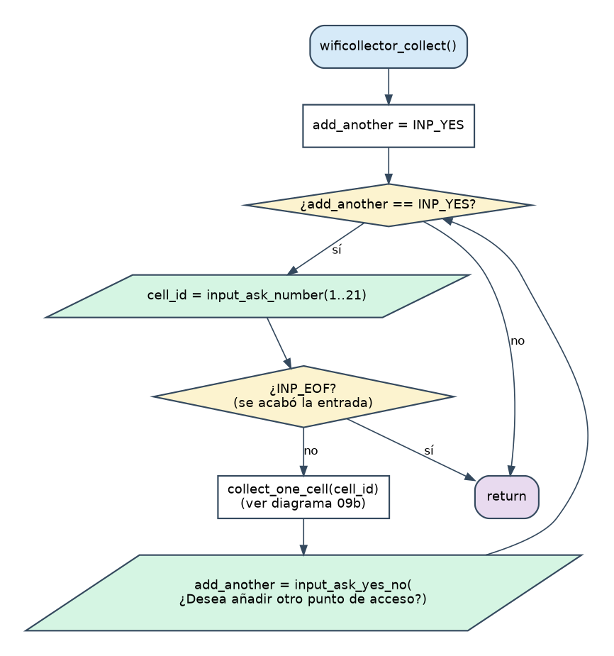

Bucle externo: wificollector_collect

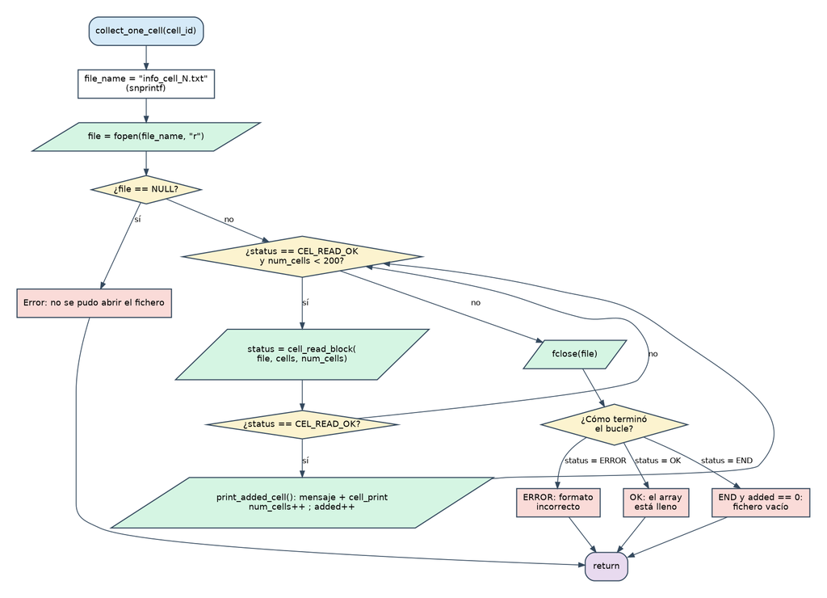

Función interna: collect_one_cell

## 5.3 Ficha: lo que debes escribir

**`wificollector.h`**: añade `void wificollector_collect(void);`

**`wificollector.c`**:

[output not shown]

**`main.c`**: añade `case MNU_COLLECT: wificollector_collect(); break;`

**`Makefile`**: ahora `wificollector.o` depende también de `cell.h`, y `main` necesita enlazar `cell.o`.

## 5.4 Pistas

> **Pista 1.** Empieza por `collect_one_cell`. Pruébala de forma provisional llamándola desde `main` con un número fijo, antes de escribir el bucle de preguntas.

> **Pista 2.** El mensaje de “array lleno” se imprime cuando el bucle termina con `status == CEL_READ_OK`: es la única forma de salir del bucle *sin* haber llegado al final ni a un error. Ponle un comentario, porque no es obvio.

> **Pista 3.** Si tras `make` ves `undefined reference to 'cell_print'`, te falta `cell.o` en la línea de enlace de `main`.

## 5.5 Pruebas

Reproduce primero **el ejemplo del enunciado** (mensaje “Fase I”):

```
printf '2\n1\ns\n7\nn\n10\n1\ns\n' | ./main
```

Debes ver las celdas de `info_cell_1.txt` en las posiciones **0, 1 y 2**, y las de `info_cell_7.txt` en la **3 y 4**, con el formato idéntico al del enunciado. Después:

| Prueba | Resultado esperado |
| --- | --- |
| Celda `abc`, vacío, `0`, `22` | Error y repregunta |
| Responder `x` a “¿otro punto de acceso?” | Error y repregunta |
| Renombrar temporalmente `info_cell_5.txt` y pedir la celda 5 | Mensaje de error y **el programa sigue** |
| Fichero vacío / truncado / con palabra clave cambiada (copias de prueba) | El mensaje correspondiente, sin caerse |
| Llenar el array (ver abajo) | Se añade hasta la posición **199** y luego “array lleno” |

Para llenar el array sin teclear 200 veces:

```
( printf '2\n'; for i in $(seq 1 69); do printf '1\ns\n'; done; printf '1\nn\n1\ns\n' ) | ./main | grep -E "Aviso|posición 19[89] "
```

(Opción 2; 69 veces “celda 1, sí”; otra vez “celda 1, no”; salir.) Esto añade 70 × 3 = 210 bloques en total: tiene que parar en la posición 199 y avisar.

## 5.6 Errores típicos

- Incrementar `num_cells` **antes** de imprimir/usar la posición: te desplazas una posición.
- Comprobar `num_cells <= WFC_MAX_CELLS` (con `<=`): permite escribir en la posición 200. Es el clásico *off-by-one*.
- No cerrar el fichero cuando falla algo a mitad.
- Reservar el nombre del fichero con muy poco espacio y usar `sprintf`.

## 5.7 Solución de referencia

**Ver mi solución: wificollector.h, wificollector.c, main.c y Makefile**

**`etapa_5/wificollector.h`**

```c
#ifndef _WIFICOLLECTOR_H_
#define _WIFICOLLECTOR_H_

/* Pregunta si se quiere salir. Devuelve 1 si el usuario confirma, 0 si no */
int wificollector_quit(void);

/* Lee los puntos de acceso de ficheros info_cell_N.txt y los guarda */
void wificollector_collect(void);

#endif /* _WIFICOLLECTOR_H_ */
```

**`etapa_5/wificollector.c`**

```c
#include <stdio.h>
#include "wificollector.h"
#include "cell.h"
#include "input.h"

/* Número de celda mínimo: corresponde al fichero info_cell_1.txt */
#define WFC_MIN_CELL_ID 1

/* Número de celda máximo: corresponde al fichero info_cell_21.txt */
#define WFC_MAX_CELL_ID 21

/* Número máximo de puntos de acceso que caben en el array */
#define WFC_MAX_CELLS 200

/* Tamaño máximo del nombre de un fichero (incluye el '\0' final) */
#define WFC_MAX_FILE_NAME 80

/* Variables globales (solo visibles dentro de este fichero) */

/* Array con los puntos de acceso recolectados hasta el momento */
static struct wifi_cell cells[WFC_MAX_CELLS];

/* Número de posiciones del array que están ocupadas */
static int num_cells = 0;

/*
 * wificollector_quit()
 * Pregunta al usuario si de verdad quiere salir del programa.
 * Devuelve 1 si el usuario confirma y 0 si decide seguir.
 */
int wificollector_quit(void)
{
    int answer;

    answer = input_ask_yes_no(
        "¿Está seguro de que desea salir del programa? [s/N]: ");

    if (answer == INP_YES)
    {
        printf("¡Hasta pronto!\n");
        return 1;
    }

    return 0;
}

/*
 * print_added_cell()
 * Confirma que se ha añadido un punto de acceso al array y lo imprime.
 */
static void print_added_cell(const char file_name[], int position)
{
    printf("Datos leídos de %s (añadidos a la posición %d del array)\n",
        file_name, position);
    cell_print(cells[position]);
    printf("\n");
}

/*
 * collect_one_cell()
 * Abre el fichero info_cell_N.txt y añade al array todos los puntos de acceso
 * que contiene, hasta que se acabe el fichero o se llene el array.
 */
static void collect_one_cell(int cell_id)
{
    char file_name[WFC_MAX_FILE_NAME];
    cell_read_status_t status = CEL_READ_OK;
    FILE *file;
    int added = 0;

    snprintf(file_name, WFC_MAX_FILE_NAME, "info_cell_%d.txt", cell_id);
    file = fopen(file_name, "r");
    if (file == NULL)
    {
        printf("Error: no se pudo abrir el fichero %s\n\n", file_name);
        return;
    }

    while (status == CEL_READ_OK && num_cells < WFC_MAX_CELLS)
    {
        status = cell_read_block(file, cells, num_cells);
        if (status == CEL_READ_OK)
        {
            print_added_cell(file_name, num_cells);
            num_cells++;
            added++;
        }
    }
    fclose(file);

    if (status == CEL_READ_ERROR)
    {
        printf("Error: formato incorrecto en %s (se ignora el resto)\n\n",
            file_name);
    }
    else if (status == CEL_READ_OK)
    {
        /* El bucle terminó con un bloque correcto: el array está lleno */
        printf("Aviso: el array está lleno (%d posiciones). No se añaden "
            "más datos.\n\n", WFC_MAX_CELLS);
    }
    else if (added == 0)
    {
        printf("El fichero %s no contiene datos\n\n", file_name);
    }
}

/*
 * wificollector_collect()
 * Pide un número de celda, añade al array los datos de su fichero y pregunta
 * si se quiere añadir otra celda. Repite mientras el usuario responda "s".
 */
void wificollector_collect(void)
{
    int cell_id;
    int add_another = INP_YES;

    while (add_another == INP_YES)
    {
        cell_id = input_ask_number("¿Qué celda quiere recolectar? (1 - 21): ",
            WFC_MIN_CELL_ID, WFC_MAX_CELL_ID);
        if (cell_id == INP_EOF)
        {
            return;
        }

        collect_one_cell(cell_id);

        add_another = input_ask_yes_no(
            "¿Desea añadir otro punto de acceso? [s/N]: ");
    }
}
```

**`etapa_5/main.c`**

```c
#include <stdio.h>
#include "input.h"
#include "wificollector.h"

/* Número de operaciones que muestra el menú principal */
#define MNU_NUM_OPTIONS 10

/*
 * menu_option_t
 * Operaciones del menú principal. El valor de cada una coincide con el número
 * que se muestra en pantalla (por eso la primera vale 1 y no 0).
 */
typedef enum
{
    MNU_QUIT = 1,
    MNU_COLLECT,
    MNU_SHOW_DATA_ONE_NETWORK,
    MNU_SELECT_BEST,
    MNU_DELETE_NET,
    MNU_SORT,
    MNU_EXPORT,
    MNU_IMPORT,
    MNU_DISPLAY,
    MNU_DISPLAY_ALL
} menu_option_t;

/*
 * print_menu()
 * Muestra por pantalla el menú principal con todas las operaciones.
 */
static void print_menu(void)
{
    printf("\n[2026] SAUCEM S.L. Recolector de redes inalámbricas\n\n");
    printf("    [ 1] wificollector_quit\n");
    printf("    [ 2] wificollector_collect\n");
    printf("    [ 3] wificollector_show_data_one_network\n");
    printf("    [ 4] wificollector_select_best\n");
    printf("    [ 5] wificollector_delete_net\n");
    printf("    [ 6] wificollector_sort\n");
    printf("    [ 7] wificollector_export\n");
    printf("    [ 8] wificollector_import\n");
    printf("    [ 9] wificollector_display\n");
    printf("    [10] wificollector_display_all\n\n");
}

/*
 * main()
 * Muestra el menú una y otra vez y ejecuta la operación elegida hasta que el
 * usuario confirma que quiere salir (o se acaba la entrada de datos).
 */
int main(void)
{
    int option;
    int exit_requested = 0;

    while (!exit_requested)
    {
        print_menu();
        option = input_ask_number("    Opción elegida: ", 1, MNU_NUM_OPTIONS);

        switch (option)
        {
            case INP_EOF:
                printf("\nFin de la entrada de datos.\n");
                exit_requested = 1;
                break;
            case MNU_QUIT:
                exit_requested = wificollector_quit();
                break;
            case MNU_COLLECT:
                wificollector_collect();
                break;
            default:
                printf("Esa operación todavía no está implementada.\n");
                break;
        }
    }

    return 0;
}
```

**`etapa_5/Makefile`**

```
# Makefile - Etapa 5: wificollector_collect
# Compilar:  make        Ejecutar:  ./main        Limpiar:  make clean

CC = gcc
CFLAGS = -Wall -g

main: main.o input.o wificollector.o cell.o
    $(CC) $(CFLAGS) -o main main.o input.o wificollector.o cell.o

test_input: test_input.o input.o
    $(CC) $(CFLAGS) -o test_input test_input.o input.o

test_cell_print: test_cell_print.o cell.o
    $(CC) $(CFLAGS) -o test_cell_print test_cell_print.o cell.o

test_cell_read: test_cell_read.o cell.o
    $(CC) $(CFLAGS) -o test_cell_read test_cell_read.o cell.o

main.o: main.c input.h wificollector.h
    $(CC) $(CFLAGS) -c main.c

input.o: input.c input.h
    $(CC) $(CFLAGS) -c input.c

wificollector.o: wificollector.c wificollector.h input.h cell.h
    $(CC) $(CFLAGS) -c wificollector.c

cell.o: cell.c cell.h
    $(CC) $(CFLAGS) -c cell.c

test_input.o: test_input.c input.h
    $(CC) $(CFLAGS) -c test_input.c

test_cell_print.o: test_cell_print.c cell.h
    $(CC) $(CFLAGS) -c test_cell_print.c

test_cell_read.o: test_cell_read.c cell.h
    $(CC) $(CFLAGS) -c test_cell_read.c

clean:
    rm -f *.o main test_input test_cell_print test_cell_read

.PHONY: clean
```

## 5.8 Recursos

- [`snprintf`](https://en.cppreference.com/w/c/io/fprintf) · [`fclose`](https://en.cppreference.com/w/c/io/fclose)
- Buscar: “off-by-one error array bounds C”
- Beej’s Guide to C: capítulos sobre *Scope* y variables `static`

## 5.9 Lista de comprobación

- El ejemplo del enunciado sale idéntico (posiciones 0-4)
- El array lleno se detiene en la 199 y avisa
- Ningún error de usuario (número, fichero, formato) rompe el programa
- Sé explicar por qué escribir en `cells[200]` es peligroso aunque compile
- He reescrito `collect_one_cell` sin mirar

# Etapa 6 · `display` y `display_all`

> **Objetivo:** consultar lo que hay en el array: las celdas de un número concreto (`display`) o todas (`display_all`). **Dificultad:** baja. Es la etapa para consolidar. **Tiempo orientativo:** 1 sesión.

## 6.1 Teoría

### Búsqueda lineal

Para encontrar todos los elementos que cumplen una condición, se **recorre el array entero** comparando uno a uno. Con `num_cells` elementos ocupados, el recorrido es de `0` a `num_cells - 1`:

```c
for (i = 0; i < num_cells; i++)
{
    if (cells[i].cell_id == cell_id)
    {
        /* este punto de acceso es de la celda buscada */
    }
}
```

Recorre solo hasta `num_cells`, **no hasta 200**: las posiciones libres contienen basura.

### Una función que devuelve “cuántos”

`print_cells_with_id` imprime los que coinciden **y devuelve cuántos ha encontrado**. Quien la llama (`wificollector_display`) usa ese número para decidir si muestra el error “celda no recolectada”. Así, la búsqueda y la decisión quedan separadas, y la función es fácil de entender y de reutilizar.

### Lo que dice el enunciado de `display`

- Si se pide una celda que no se ha añadido con `collect`: **mensaje de error**.
- **“En cualquier caso”** (con éxito o con error) hay que preguntar `"¿Desea imprimir la información de otra celda? [s/N]: "` y, si es `s`, repetir. Es decir, el error **no** interrumpe el bucle.

### Texto en dos líneas

El enunciado muestra la pregunta partida en dos líneas. Como la guía limita el ancho del código a 80 columnas, parte el literal en dos trozos adyacentes (C los pega) e incluye `\n` donde corresponda:

```c
"Indique el número de la celda de la que desea conocer su\n"
"información (1 - 21): "
```

## 6.2 Diagrama de flujo

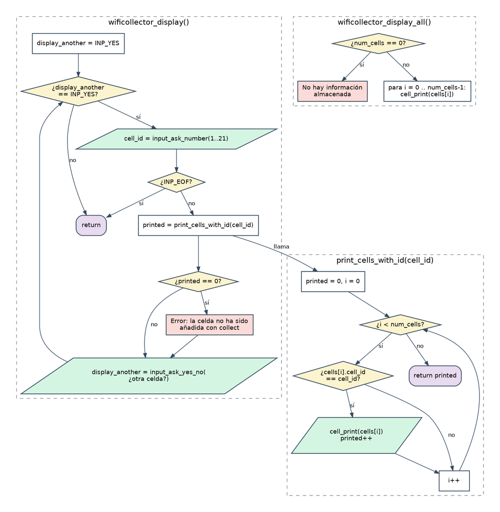

display, su función auxiliar y display_all

## 6.3 Ficha: lo que debes escribir

**`wificollector.h`**: añade los prototipos de `wificollector_display` y `wificollector_display_all`.

**`wificollector.c`**:

| Función | Descripción |
| --- | --- |
| `static int print_cells_with_id(int cell_id)` | Imprime (con `cell_print`) los puntos de acceso guardados con ese `cell_id`. Devuelve cuántos imprimió |
| `void wificollector_display(void)` | Bucle: pide el número (1-21; si `INP_EOF`, `return`), imprime con la función anterior, y si no imprimió ninguno muestra un error. **Siempre** pregunta si se quiere consultar otra |
| `void wificollector_display_all(void)` | Si `num_cells == 0`, avisa de que no hay información. Si no, imprime todas **en orden de inserción** |

**`main.c`**: añade los `case` de `MNU_DISPLAY` y `MNU_DISPLAY_ALL`.

## 6.4 Pistas

> **Pista 1.** `wificollector_display` tiene la misma estructura que `wificollector_collect`: un bucle controlado por la respuesta sí/no. Copia **la forma**, no el texto: ya sabes escribirla.

> **Pista 2.** El mensaje de error de “celda no añadida” no es una pregunta: no hace falta `input_...` para él, basta un `printf`.

## 6.5 Pruebas

```
printf '2\n1\ns\n7\nn\n10\n9\n7\nn\n1\ns\n' | ./main
```

(Es el ejemplo completo del enunciado: collect 1 y 7, display_all, display de la 7, salir.)

| Prueba | Resultado esperado |
| --- | --- |
| `display_all` con el array vacío | Mensaje de “no hay información” |
| `display` de una celda **no** recolectada | Error, y **aun así** pregunta si se quiere otra |
| `display` de una celda con 3 puntos de acceso | Los 3, en el orden en que se añadieron |
| Recolectar la misma celda **dos veces** y `display` | Los puntos aparecen duplicados (decisión documentada en la portada) |
| `display` y Ctrl+D en mitad de la pregunta | Vuelve al menú y luego termina sin colgarse |

## 6.6 Errores típicos

- Recorrer hasta `WFC_MAX_CELLS` en vez de `num_cells`: imprime basura.
- Usar `=` en vez de `==` dentro del `if`.
- Olvidar la pregunta de “otra celda” cuando hay error (el enunciado dice “en cualquier caso”).

## 6.7 Solución de referencia

**Ver mi solución: wificollector.h, wificollector.c y main.c**

**`etapa_6/wificollector.h`**

```c
#ifndef _WIFICOLLECTOR_H_
#define _WIFICOLLECTOR_H_

/* Pregunta si se quiere salir. Devuelve 1 si el usuario confirma, 0 si no */
int wificollector_quit(void);

/* Lee los puntos de acceso de ficheros info_cell_N.txt y los guarda */
void wificollector_collect(void);

/* Imprime los puntos de acceso guardados de la celda que elija el usuario */
void wificollector_display(void);

/* Imprime todos los puntos de acceso guardados */
void wificollector_display_all(void);

#endif /* _WIFICOLLECTOR_H_ */
```

**`etapa_6/wificollector.c`**

```c
#include <stdio.h>
#include "wificollector.h"
#include "cell.h"
#include "input.h"

/* Número de celda mínimo: corresponde al fichero info_cell_1.txt */
#define WFC_MIN_CELL_ID 1

/* Número de celda máximo: corresponde al fichero info_cell_21.txt */
#define WFC_MAX_CELL_ID 21

/* Número máximo de puntos de acceso que caben en el array */
#define WFC_MAX_CELLS 200

/* Tamaño máximo del nombre de un fichero (incluye el '\0' final) */
#define WFC_MAX_FILE_NAME 80

/* Variables globales (solo visibles dentro de este fichero) */

/* Array con los puntos de acceso recolectados hasta el momento */
static struct wifi_cell cells[WFC_MAX_CELLS];

/* Número de posiciones del array que están ocupadas */
static int num_cells = 0;

/*
 * wificollector_quit()
 * Pregunta al usuario si de verdad quiere salir del programa.
 * Devuelve 1 si el usuario confirma y 0 si decide seguir.
 */
int wificollector_quit(void)
{
    int answer;

    answer = input_ask_yes_no(
        "¿Está seguro de que desea salir del programa? [s/N]: ");

    if (answer == INP_YES)
    {
        printf("¡Hasta pronto!\n");
        return 1;
    }

    return 0;
}

/*
 * print_added_cell()
 * Confirma que se ha añadido un punto de acceso al array y lo imprime.
 */
static void print_added_cell(const char file_name[], int position)
{
    printf("Datos leídos de %s (añadidos a la posición %d del array)\n",
        file_name, position);
    cell_print(cells[position]);
    printf("\n");
}

/*
 * collect_one_cell()
 * Abre el fichero info_cell_N.txt y añade al array todos los puntos de acceso
 * que contiene, hasta que se acabe el fichero o se llene el array.
 */
static void collect_one_cell(int cell_id)
{
    char file_name[WFC_MAX_FILE_NAME];
    cell_read_status_t status = CEL_READ_OK;
    FILE *file;
    int added = 0;

    snprintf(file_name, WFC_MAX_FILE_NAME, "info_cell_%d.txt", cell_id);
    file = fopen(file_name, "r");
    if (file == NULL)
    {
        printf("Error: no se pudo abrir el fichero %s\n\n", file_name);
        return;
    }

    while (status == CEL_READ_OK && num_cells < WFC_MAX_CELLS)
    {
        status = cell_read_block(file, cells, num_cells);
        if (status == CEL_READ_OK)
        {
            print_added_cell(file_name, num_cells);
            num_cells++;
            added++;
        }
    }
    fclose(file);

    if (status == CEL_READ_ERROR)
    {
        printf("Error: formato incorrecto en %s (se ignora el resto)\n\n",
            file_name);
    }
    else if (status == CEL_READ_OK)
    {
        /* El bucle terminó con un bloque correcto: el array está lleno */
        printf("Aviso: el array está lleno (%d posiciones). No se añaden "
            "más datos.\n\n", WFC_MAX_CELLS);
    }
    else if (added == 0)
    {
        printf("El fichero %s no contiene datos\n\n", file_name);
    }
}

/*
 * wificollector_collect()
 * Pide un número de celda, añade al array los datos de su fichero y pregunta
 * si se quiere añadir otra celda. Repite mientras el usuario responda "s".
 */
void wificollector_collect(void)
{
    int cell_id;
    int add_another = INP_YES;

    while (add_another == INP_YES)
    {
        cell_id = input_ask_number("¿Qué celda quiere recolectar? (1 - 21): ",
            WFC_MIN_CELL_ID, WFC_MAX_CELL_ID);
        if (cell_id == INP_EOF)
        {
            return;
        }

        collect_one_cell(cell_id);

        add_another = input_ask_yes_no(
            "¿Desea añadir otro punto de acceso? [s/N]: ");
    }
}

/*
 * print_cells_with_id()
 * Imprime los puntos de acceso guardados cuyo identificador de celda es
 * "cell_id". Devuelve cuántos ha impreso.
 */
static int print_cells_with_id(int cell_id)
{
    int printed = 0;
    int i;

    for (i = 0; i < num_cells; i++)
    {
        if (cells[i].cell_id == cell_id)
        {
            cell_print(cells[i]);
            printed++;
        }
    }

    return printed;
}

/*
 * wificollector_display()
 * Pide un número de celda e imprime sus puntos de acceso guardados. Si no hay
 * ninguno, muestra un error. Después pregunta si se quiere consultar otra.
 */
void wificollector_display(void)
{
    int cell_id;
    int display_another = INP_YES;

    while (display_another == INP_YES)
    {
        cell_id = input_ask_number(
            "Indique el número de la celda de la que desea conocer su\n"
            "información (1 - 21): ", WFC_MIN_CELL_ID, WFC_MAX_CELL_ID);
        if (cell_id == INP_EOF)
        {
            return;
        }

        if (print_cells_with_id(cell_id) == 0)
        {
            printf("Error: la celda %d no ha sido añadida con "
                "wificollector_collect.\n", cell_id);
        }

        printf("\n");
        display_another = input_ask_yes_no(
            "¿Desea imprimir la información de otra celda? [s/N]: ");
    }
}

/*
 * wificollector_display_all()
 * Imprime todos los puntos de acceso guardados, en el orden en que se
 * añadieron.
 */
void wificollector_display_all(void)
{
    int i;

    if (num_cells == 0)
    {
        printf("No hay información almacenada. Use wificollector_collect.\n");
        return;
    }

    for (i = 0; i < num_cells; i++)
    {
        cell_print(cells[i]);
    }
}
```

**`etapa_6/main.c`**

```c
#include <stdio.h>
#include "input.h"
#include "wificollector.h"

/* Número de operaciones que muestra el menú principal */
#define MNU_NUM_OPTIONS 10

/*
 * menu_option_t
 * Operaciones del menú principal. El valor de cada una coincide con el número
 * que se muestra en pantalla (por eso la primera vale 1 y no 0).
 */
typedef enum
{
    MNU_QUIT = 1,
    MNU_COLLECT,
    MNU_SHOW_DATA_ONE_NETWORK,
    MNU_SELECT_BEST,
    MNU_DELETE_NET,
    MNU_SORT,
    MNU_EXPORT,
    MNU_IMPORT,
    MNU_DISPLAY,
    MNU_DISPLAY_ALL
} menu_option_t;

/*
 * print_menu()
 * Muestra por pantalla el menú principal con todas las operaciones.
 */
static void print_menu(void)
{
    printf("\n[2026] SAUCEM S.L. Recolector de redes inalámbricas\n\n");
    printf("    [ 1] wificollector_quit\n");
    printf("    [ 2] wificollector_collect\n");
    printf("    [ 3] wificollector_show_data_one_network\n");
    printf("    [ 4] wificollector_select_best\n");
    printf("    [ 5] wificollector_delete_net\n");
    printf("    [ 6] wificollector_sort\n");
    printf("    [ 7] wificollector_export\n");
    printf("    [ 8] wificollector_import\n");
    printf("    [ 9] wificollector_display\n");
    printf("    [10] wificollector_display_all\n\n");
}

/*
 * main()
 * Muestra el menú una y otra vez y ejecuta la operación elegida hasta que el
 * usuario confirma que quiere salir (o se acaba la entrada de datos).
 */
int main(void)
{
    int option;
    int exit_requested = 0;

    while (!exit_requested)
    {
        print_menu();
        option = input_ask_number("    Opción elegida: ", 1, MNU_NUM_OPTIONS);

        switch (option)
        {
            case INP_EOF:
                printf("\nFin de la entrada de datos.\n");
                exit_requested = 1;
                break;
            case MNU_QUIT:
                exit_requested = wificollector_quit();
                break;
            case MNU_COLLECT:
                wificollector_collect();
                break;
            case MNU_DISPLAY:
                wificollector_display();
                break;
            case MNU_DISPLAY_ALL:
                wificollector_display_all();
                break;
            default:
                printf("Esa operación todavía no está implementada.\n");
                break;
        }
    }

    return 0;
}
```

## 6.8 Recursos

- [`for`](https://en.cppreference.com/w/c/language/for) · [Búsqueda lineal](https://en.wikipedia.org/wiki/Linear_search)
- Beej’s Guide to C: capítulo *Arrays*

## 6.9 Lista de comprobación

- El ejemplo completo del enunciado coincide
- Los datos de `display_all` salen en orden de inserción
- `display` pregunta “¿otra celda?” también tras un error
- Sé explicar por qué se recorre hasta `num_cells`
- He reescrito `print_cells_with_id` sin mirar

# Etapa 7 · Pruebas, estilo y entrega

> **Objetivo:** convertir un programa que “funciona en mi ordenador” en una entrega que **cumple todos los requisitos** y que puedes defender. Esta etapa vale tanto como las anteriores: la nota se pierde aquí si no se hace con cuidado. **Dificultad:** baja, pero **meticulosa**. **Tiempo orientativo:** 1 sesión (¡no el último día!).

## 7.1 Probar con redirección de entrada (y automatizarlo)

Hasta ahora has probado escribiendo. Un programa de terminal se puede probar **sin teclado**, redirigiendo un fichero a su entrada:

```
./main < tests/01_ejemplo_enunciado.in
```

Cada línea del `.in` es lo que habrías tecleado. La salida **no** muestra lo que “escribes” (no hay eco), por eso los prompts aparecen pegados. Si guardas la salida buena como “esperada”, puedes **comparar** automáticamente con `diff`:

```
./main < tests/01_ejemplo_enunciado.in | diff - tests/01_ejemplo_enunciado.out
```

Si `diff` no imprime nada, la salida es idéntica. La carpeta `etapa_7_entrega_final/tests/` incluye tres pruebas y un script que las ejecuta todas:

```
sh tests/run_tests.sh
```

| Prueba | Qué comprueba |
| --- | --- |
| `01_ejemplo_enunciado` | El ejemplo exacto del mensaje de la Fase I |
| `02_robustez_teclado` | Basura en el menú, números, sí/no, línea de 200 caracteres, fichero correcto tras errores |
| `03_fin_de_entrada` | La entrada se acaba sin salir del programa (Ctrl+D): no debe colgarse |
| *(extra en el script)* | Llenar el array hasta 200 |

> **Cuidado con esto:** los `.out` esperados los generó **mi** programa y los he revisado a mano, pero son una *foto* de que “hoy se comporta así”. Si cambias un mensaje a propósito, regenera con `sh tests/run_tests.sh --update` **después de comprobar** que el cambio es el que querías. Esta herramienta detecta *regresiones* (algo que antes funcionaba y se rompe), no te dice que el comportamiento original sea el correcto.

**Tu tarea:** escribe **al menos dos pruebas propias** nuevas (por ejemplo, un fichero `info_cell_N.txt` roto copiado a otro nombre y recolectado, o recolectar las 21 celdas y hacer `display_all`).

## 7.2 Matriz de robustez

El enunciado enumera los casos que “no deben romper el programa”. Compruébalos **todos**, en **todas** las preguntas que haga el programa:

| Caso del enunciado | Dónde probarlo | Esperado |
| --- | --- | --- |
| Letras cuando se espera un número | Menú, celda de `collect`, celda de `display` | Error y repregunta |
| Cadena vacía / línea vacía | Menú, celdas, **todas** las preguntas sí/no | Error y repregunta |
| Número fuera de rango | Menú (1-10), celdas (1-21) | Error y repregunta |
| Nombre de fichero incorrecto | `collect` con un `info_cell_N.txt` ausente | Mensaje y vuelve al menú |
| Fichero vacío | `collect` con un fichero vacío | “No contiene datos” |
| Fichero con formato incorrecto/truncado | `collect` con una copia dañada | Error, conserva lo leído antes |
| Línea muy larga | Cualquier pregunta con 200+ caracteres | Un solo error; la siguiente lectura sale bien |
| Fin de entrada (Ctrl+D) | Cualquier pregunta | Termina sin colgarse |
| Array lleno | `collect` repetido | Aviso y sin desbordar |

## 7.3 Revisión de estilo (el `company_require_style`)

Haz este repaso con el código final. Los comandos se ejecutan en la carpeta del proyecto.

**Automático.** Ejecuta estos cuatro comandos en la carpeta del proyecto. **Los cuatro deben terminar sin mostrar nada** (salvo el último, que debe mostrar un `OK` por cada `.h`):

```
# 1) Cero advertencias al compilar desde cero
make clean && make 2>&1 | grep -i warning

# 2) Ninguna línea de más de 80 caracteres (el tabulador cuenta como 4)
awk '{ gsub(/\t/, "    "); if (length($0) > 80) print FILENAME": "FNR }' *.c *.h

# 3) Ninguna sangría con espacios (la guía exige tabuladores)
grep -nP '^ {2,}' *.c *.h

# 4) Cada .h compila por sí solo, es decir, incluye lo imprescindible (regla E6)
for h in *.h; do printf '#include "%s"\nint main(void)\n{\n\treturn 0;\n}\n' $h | gcc -Wall -I. -x c -fsyntax-only - && echo "OK $h"; done
```

Sobre el comando 3: las líneas de comentario del estilo `* texto` empiezan por **un** solo espacio, y eso es correcto; por eso se busca “dos o más espacios”.

> El `awk` cuenta **bytes**, no caracteres. Si una línea con tildes (`á`, `ñ`…) sale marcada pero a simple vista mide ≤ 80, comprueba en tu editor con la raya de la columna 80.

**A ojo (marca cada punto):**

- Toda función de un `.c` (también las `static`) lleva su comentario encima
- Todo `#define`, `struct`, campo de `struct`, `enum` y variable global está documentado
- Ninguna función ocupa más de dos pantallas (idealmente, una)
- Llaves Allman (`{` en su propia línea), espacio tras `if`/`for`/`while`/`return`, espacio alrededor de los operadores
- Nombres en minúsculas con `_` (funciones/variables) y MAYÚSCULAS (macros), con prefijo de módulo en lo público
- Ningún número “mágico” suelto: los tamaños son macros
- Los `.h` tienen guarda y solo lo público; los `.c` incluyen primero su propio `.h`
- Lo privado es `static`; las globales, juntas arriba y `static`
- No queda ningún `printf` de depuración ni código comentado

## 7.4 El README

El enunciado pide un archivo de texto `README`. Hay una **plantilla** en `etapa_7_entrega_final/README.txt` con la estructura (cómo compilar y ejecutar, qué operaciones hay, organización del código, decisiones de diseño, pruebas, limitaciones). **Es una plantilla: reescríbela con vuestras palabras** y con los nombres de los miembros del equipo. Un buen README responde en un minuto a: *¿cómo lo compilo? ¿qué hace? ¿qué decisiones tomasteis donde el enunciado no era claro? ¿qué falta?*

## 7.5 Empaquetar y probar la entrega

El enunciado pide un archivo comprimido con: **archivos de entrada, código fuente, `Makefile` y `README`**, y que se compile con `make` y se ejecute con `./main`.

```
make clean                       # no entregues ejecutables ni .o
cd ..
zip -r entrega1.zip wificollector/
```

**Prueba la entrega como la recibiría el profesor:**

```
mkdir /tmp/prueba && cd /tmp/prueba
unzip ~/entrega1.zip
cd wificollector
make
./main
```

Y, sobre todo: **repite esto en un laboratorio o máquina virtual de la UC3M**. El enunciado dice que, si no compila ni ejecuta allí, *“su trabajo no será considerado válido”*. Las diferencias típicas entre tu ordenador y el laboratorio son la versión de `gcc` y las rutas de los ficheros de datos.

**Lista de entrega:**

- `make` desde cero compila sin errores **ni advertencias**
- `./main` arranca y el ejemplo del enunciado sale igual
- Los 21 `info_cell_N.txt` van **dentro** del `.zip`
- El `README` está reescrito y firmado por el equipo
- Probado en el laboratorio / máquina virtual de la UC3M
- Subido a Aula Global **antes** de las 23:55 del viernes 16 de octubre (con margen)

## 7.6 Mirando hacia delante: qué cambia en las entregas 2 y 3

Según el enunciado:

| Entrega | Novedades | Qué parte de tu código cambia |
| --- | --- | --- |
| 2 (13 nov) | Arrays **dinámicos** (empiezan en 5, `realloc` de 5 en 5), `wificollector_sort`; borrar un elemento desplazando a la izquierda | `cells` y `num_cells` pasan a ser puntero + contador + capacidad; `collect` necesita comprobar “¿cabe?” y crecer |
| 3 (11 dic) | **Listas** enlazadas, `import`/`export` con ficheros binarios; liberar toda la memoria | Cambia la estructura de datos entera; aparece `free` |

Lo que has hecho bien ahora **se reutiliza casi entero**: `input`, `cell_read_block`, `cell_print`, el menú. Eso es lo bueno de haber separado en módulos: solo `wificollector.c` tendrá que cambiar de verdad. Y es aquí donde los punteros dejarán de ser “magia” para ser herramienta.

## 7.7 Autoevaluación: ¿puedes hacerlo sin la IA?

Esta es la prueba de verdad del objetivo que te marcaste. Responde **sin mirar** el código ni la guía; luego comprueba.

**Preguntas de concepto**

1. ¿Qué devuelve `sscanf("12x", "%d %c", &n, &c)` y por qué lo usamos para validar un entero?
2. ¿Por qué `char line[80]` solo admite 79 caracteres de texto?
3. ¿Qué diferencia hay entre `%s` y `%79s` en `sscanf`? ¿Y entre `%s` y `%[^"]`?
4. ¿Qué ocurriría si `collect_one_cell` no comprobara `num_cells < WFC_MAX_CELLS`?
5. ¿Qué significa `static` en una función? ¿Y en una variable global?
6. ¿Por qué se pasa `size` a `input_read_line` si ya está declarado el array?
7. ¿Qué error obtienes si declaras una función en un `.h` pero nunca la escribes? ¿Y si la escribes pero se te olvida el `#include` del `.h`?

**Ejercicios de programación (en papel o en el editor, con límite de tiempo)**

1. Escribe `input_read_line` desde cero en 10 minutos.
2. Escribe un `Makefile` para este proyecto desde cero en 10 minutos.
3. **Reto de ampliación:** implementa `wificollector_select_best` (opción 4): muestra el punto de acceso de mejor calidad (el mayor `quality`). Es un recorrido como el de `display_all`, pero recordando cuál es el mejor hasta el momento. ¿Qué haces si el array está vacío?
4. Escribe una función que cuente cuántas redes **sin cifrar** (`encryption` igual a `"off"`) hay guardadas. (Pista: `strcmp` de `<string.h>` compara cadenas; devuelve 0 si son iguales.)
5. Cambia la capacidad del array a 50. ¿Cuántas líneas de código tienes que tocar? ¿Por qué la regla C1 de la guía tiene sentido?

> Si un ejercicio te sale a la primera, ya dominas esa parte. Si no, no pasa nada: vuelve a la etapa correspondiente y repítela **sin** el desplegable.

# Apéndice · Chuleta de las funciones de C que has usado

| Función | Cabecera | Qué hace | Ojo con… |
| --- | --- | --- | --- |
| `printf(fmt, ...)` | `<stdio.h>` | Escribe texto con formato en pantalla | El formato debe coincidir con el tipo (`%d` int, `%s` cadena, `%f` double) |
| `fgets(buf, size, f)` | `<stdio.h>` | Lee una línea (como mucho `size - 1` caracteres) | Guarda el `\n`; devuelve `NULL` al acabar |
| `getchar()` | `<stdio.h>` | Lee **un** carácter del teclado | Devuelve `int` (para poder valer `EOF`) |
| `sscanf(texto, fmt, ...)` | `<stdio.h>` | Extrae datos de una cadena | Devuelve **cuántos** convirtió; necesita `&` en los números; limita `%s` con anchura |
| `snprintf(buf, size, fmt, ...)` | `<stdio.h>` | Como `printf` pero escribiendo en una cadena | `size` evita desbordamientos |
| `fopen(nombre, modo)` | `<stdio.h>` | Abre un fichero (`"r"` leer) | Devuelve `NULL` si falla: **siempre** comprobar |
| `fclose(f)` | `<stdio.h>` | Cierra el fichero | Una por cada `fopen` que haya funcionado |
| `strlen(s)` | `<string.h>` | Longitud de una cadena (sin el `'\0'`) | Recorre toda la cadena: no la llames en bucles innecesariamente |
| `strcpy(dest, orig)` | `<string.h>` | Copia una cadena | **No** comprueba el tamaño del destino |
| `strcmp(a, b)` | `<string.h>` | Compara cadenas | Devuelve **0** si son iguales (no `1`) |

**Operadores y construcciones**

| Elemento | Resumen |
| --- | --- |
| `&x` | “Dirección de `x`”: dónde escribir un resultado (`sscanf`) |
| `==` frente a `=` | `==` compara; `=` asigna. Confundirlos es un clásico |
| `a[i]`, `a[0]`…`a[n-1]` | Un array de `n` elementos va de la posición `0` a la `n-1` |
| `x.campo` | Acceso a un campo de una `struct` |
| `x = y` (structs) | Copia **todos** los campos, también los arrays internos |
| `+=`, `++` | `a += b` es `a = a + b`; `i++` suma 1 a `i` |
| `enum` | Nombres para una serie de enteros |
| `static` (función o global) | Solo visible dentro de ese `.c` |
| `const` en un parámetro | Promesa de no modificarlo |

**Mensajes del compilador que ya sabes leer**

| Mensaje | Significado habitual |
| --- | --- |
| `implicit declaration of function 'x'` | Falta `#include` o el prototipo de `x` |
| `unused variable 'x'` | Declaraste `x` y no la usas |
| `format '%d' expects argument of type 'int'` | El formato de `printf` no coincide con el dato |
| `undefined reference to 'x'` | (Enlazador) `x` está declarada pero no hay ningún `.o` que la defina |
| `missing separator` | (Make) La receta no empieza con un tabulador |
| `control reaches end of non-void function` | Una función con tipo de retorno puede acabar sin `return` |